# Preliminary Quality Control of Novartis DECAMP2 Nasal Brushings RNA-seq data

05 November, 2020

## Preprocessing

```r
# Load library:
library(plyr)
library(SummarizedExperiment)
library(readxl)
library(dplyr)
library(ggplot2)
library(pheatmap)
library("RColorBrewer")
library(DESeq2)
library(knitr)
library(kableExtra)

set.seed("12345")

# Load data:
se <- readRDS("/restricted/projectnb/pulmseq/Novartis/processing/work/28/da9dcb4ebb5f902c53fff1bc1ebdc2/Novartis_Gene_Expression.rds")
colnames(se) <- gsub(pattern = "_.*", "", colnames(se))

# Load annotation:

# Matches sample ID to kitnumber + Has batch info
annotManifest <- read_excel("/restricted/projectnb/pulmseq/Novartis/annotation/Novartis_RNASeq_run_manifest.xlsx")

# Matches sample ID to sample type/RIN (received from Jack, 8/24/20)
annotSampleEM0 <- read_excel("/restricted/projectnb/camplab/home/ykoga07/DECAMP/Novartis/Data/Annotation/RNA_data_for_Yusuke_08_24_20.xlsx", sheet = "EM0", skip = 2)

annotSampleEM5 <- read_excel("/restricted/projectnb/camplab/home/ykoga07/DECAMP/Novartis/Data/Annotation/RNA_data_for_Yusuke_08_24_20.xlsx", sheet = "EM5", skip = 2)

annotSampleEM6 <- read_excel("/restricted/projectnb/camplab/home/ykoga07/DECAMP/Novartis/Data/Annotation/RNA_data_for_Yusuke_08_24_20.xlsx", sheet = "EM6", skip = 2)

annotSampleEM8 <- read_excel("/restricted/projectnb/camplab/home/ykoga07/DECAMP/Novartis/Data/Annotation/RNA_data_for_Yusuke_08_24_20.xlsx", sheet = "EM8", skip = 3)

annotSampleEM15 <- read_excel("/restricted/projectnb/camplab/home/ykoga07/DECAMP/Novartis/Data/Annotation/RNA_data_for_Yusuke_08_24_20.xlsx", sheet = "EM15", skip = 3)

annotSampleEM16 <- read_excel("/restricted/projectnb/camplab/home/ykoga07/DECAMP/Novartis/Data/Annotation/RNA_data_for_Yusuke_08_24_20.xlsx", sheet = "EM16", skip = 3)

annotSampleN1 <- read_excel("/restricted/projectnb/camplab/home/ykoga07/DECAMP/Novartis/Data/Annotation/RNA_data_for_Yusuke_08_24_20.xlsx", sheet = "N1", skip = 3)

annotSampleN2 <- read_excel("/restricted/projectnb/camplab/home/ykoga07/DECAMP/Novartis/Data/Annotation/RNA_data_for_Yusuke_08_24_20.xlsx", sheet = "N2", skip = 3)

# Combine Jack's sample-based annotation file into one dataframe
annotSampleEM0 <- annotSampleEM0[, c(
  "RNA Sample ID", "DECAMP #",
  "Sample ID", "Kit Number", "Original Sample Type",
  "Isolation Date", "RIN", "DV200 (%)"
)]
colnames(annotSampleEM0) <- c(
  "RNA Sample ID", "DECAMP #",
  "Sample ID", "Kit Number", "Sample Type",
  "Isolation Date", "RIN", "DV200 (%)"
)

annotSampleEM5 <- annotSampleEM5[, c(
  "RNA Sample ID", "DECAMP #",
  "Patient ID", "Patient ID", "Sample Type",
  "Isolation Date", "RIN", "DV200 (%)"
)]
colnames(annotSampleEM5) <- c(
  "RNA Sample ID", "DECAMP #",
  "Sample ID", "Kit Number", "Sample Type",
  "Isolation Date", "RIN", "DV200 (%)"
)

annotSampleEM6 <- annotSampleEM6[, c(
  "RNA Sample ID", "DECAMP #",
  "Sample ID", "Kit Number", "Sample Type",
  "Isolation Date", "RIN", "DV200 (%)"
)]
colnames(annotSampleEM6) <- c(
  "RNA Sample ID", "DECAMP #",
  "Sample ID", "Kit Number", "Sample Type",
  "Isolation Date", "RIN", "DV200 (%)"
)

annotSampleEM8 <- annotSampleEM8[, c(
  "RNA Sample ID", "DECAMP #",
  "Sample ID", "Original Sample ID", "Sample Type",
  "Isolation Date", "RIN", "DV200 (%)"
)]
colnames(annotSampleEM8) <- c(
  "RNA Sample ID", "DECAMP #",
  "Sample ID", "Kit Number", "Sample Type",
  "Isolation Date", "RIN", "DV200 (%)"
)

annotSampleEM15 <- annotSampleEM15[, c(
  "RNA Sample ID", "DECAMP #",
  "Sample ID", "Kit Number", "Sample Type",
  "Isolation Date", "RIN", "DV200 (%)"
)]
colnames(annotSampleEM15) <- c(
  "RNA Sample ID", "DECAMP #",
  "Sample ID", "Kit Number", "Sample Type",
  "Isolation Date", "RIN", "DV200 (%)"
)

annotSampleEM16 <- annotSampleEM16[, c(
  "RNA Sample ID", "DECAMP #",
  "Sample ID", "Kit Number", "Sample Type",
  "Isolation Date", "RIN", "DV200 (%)"
)]
colnames(annotSampleEM16) <- c(
  "RNA Sample ID", "DECAMP #",
  "Sample ID", "Kit Number", "Sample Type",
  "Isolation Date", "RIN", "DV200 (%)"
)

annotSampleN1 <- annotSampleN1[, c(
  "RNA Sample ID", "DECAMP #",
  "Sample ID", "Kit Number", "Sample Type",
  "Isolation Date", "RIN", "DV200 (%)"
)]
colnames(annotSampleN1) <- c(
  "RNA Sample ID", "DECAMP #",
  "Sample ID", "Kit Number", "Sample Type",
  "Isolation Date", "RIN", "DV200 (%)"
)

annotSampleN2 <- annotSampleN2[, c(
  "RNA Sample ID", "DECAMP #",
  "Sample ID", "Kit Number", "Sample Type",
  "Isolation Date", "RIN", "DV200 (%)"
)]
colnames(annotSampleN2) <- c(
  "RNA Sample ID", "DECAMP #",
  "Sample ID", "Kit Number", "Sample Type",
  "Isolation Date", "RIN", "DV200 (%)"
)

allAnnotSamples <- ls()[grep("annotSample", ls())]
annotSample <- as.data.frame(matrix(ncol = 8))
colnames(annotSample) <- c(
  "RNA Sample ID", "DECAMP #",
  "Sample ID", "Kit Number", "Sample Type",
  "Isolation Date", "RIN", "DV200 (%)"
)
# Combine
for (x in allAnnotSamples) {
  annotSamples <- get(x)
  annotSamples$`Isolation Date` <- as.character(annotSamples$`Isolation Date`)
  annotSample <- rbind(annotSample, annotSamples)
}
annotSample <- annotSample[-which(is.na(annotSample$`RNA Sample ID`)), ]
annotSample <- annotSample[-which(is.na(annotSample$`Sample Type`)), ]

annotSample <- annotSample[-which(duplicated(annotSample$`RNA Sample ID`)), ]

# Save which samples had wrong rRNA peak when checking RIN
wrongRRNA.ix <- grep(pattern = "rong rRNA peak", annotSample$RIN)
annotSample$wrongRNAPeak <- 0
annotSample$wrongRNAPeak[wrongRRNA.ix] <- 1

# Edit RIN section to convert into numeric vector
annotSample$RIN <- gsub(pattern = "(wrong rRNA peak)", replacement = "", annotSample$RIN, fixed = TRUE)
annotSample$RIN <- gsub(pattern = "(wrong RNA peak)", replacement = "", annotSample$RIN, fixed = TRUE)
annotSample$RIN <- gsub(pattern = "(wrong rRNA peaks)", replacement = "", annotSample$RIN, fixed = TRUE)
annotSample$RIN <- gsub(pattern = "(Wrong rRNA peak)", replacement = "", annotSample$RIN, fixed = TRUE)
annotSample$RIN <- gsub(pattern = "(Wrong rRNA peaks)", replacement = "", annotSample$RIN, fixed = TRUE)
annotSample$RIN <- gsub(pattern = "\\/NA", replacement = "", annotSample$RIN)
annotSample$RIN <- gsub(pattern = ".*\\/", replacement = "", annotSample$RIN)
annotSample$RIN <- as.numeric(annotSample$RIN)
# There is a "29", probably 2.9, will ask Jack
annotSample$RIN[annotSample$RIN == 29] <- 2.9

# Consolidate nasal/bronch terms
annotSample$`Sample Type` <- gsub(pattern = ".*Bronch.*", replacement = "Bronchial Brushings", annotSample$`Sample Type`)
annotSample$`Sample Type` <- gsub(pattern = ".*Nasal.*", replacement = "Nasal Brushings", annotSample$`Sample Type`)

annotManifest <- filter(annotManifest, Run == "Run 1")
annotSample <- annotSample[annotSample$`RNA Sample ID` %in% annotManifest$Sample, ]
annotSample <- annotSample[match(annotSample$`RNA Sample ID`, annotManifest$Sample), ]

# Removing duplicate column
annotManifest$`Kit Number` <- NULL

annot <- cbind(annotManifest, annotSample)

# Clinical info:

# Matches kitnumber to randID, "Novartis_datadump"
annotDataDump2 <- read_excel("/rprojectnb/decamp/annotation/20200920/FullDECAMP2_DataDump_20200920.xlsx", sheet = "_D2CASEMAP", )

# randID to demographics info, "Novartis_datadump"
annotDataDump3 <- read_excel("/rprojectnb/decamp/annotation/20200920/FullDECAMP2_DataDump_20200920.xlsx", sheet = "_D2DEMO")

# randID to age/smoking info, "Novartis_datadump"
annotDataDump4 <- read_excel("/rprojectnb/decamp/annotation/20200920/FullDECAMP2_DataDump_20200920.xlsx", sheet = "_D2ELIGCHECK")

# randID to FEV/FVC, "Novartis_datadump"
annotDataDump5 <- read_excel("/rprojectnb/decamp/annotation/20200920/FullDECAMP2_DataDump_20200920.xlsx", sheet = "_D2PFT")
annotDataDump5 <- filter(annotDataDump5, timepoint == "Baseline Visit")

# Combine annotation info
annotA <- merge(merge(annotDataDump2, annotDataDump3, by.x = "randID", by.y = "randID"), annotDataDump4, by.x = "randID", by.y = "randID")
annotA <- merge(annotA, annotDataDump5, by.x = "randID", by.y = "randID")

# Removing patient "4796-053" as "Pacific Islander" for time being
annotA <- annotA[!(duplicated(annotA$randID)), ]

annot <- merge(annot, annotA, by.x = "Kit Number", by.y = "kitnumber", all.x = TRUE)

annotBronch <- annot[annot$`Sample Type` == "Bronchial Brushings", ]
annotNasal <- annot[annot$`Sample Type` == "Nasal Brushings", ]

uniquePatients <- length(unique(annot$`Kit Number`))

numBronch <- length(unique(annotBronch$Sample))
numNasal <- length(unique(annotNasal$Sample))

bothBronchNasal <- length(intersect(annotBronch$`Kit Number`, annotNasal$`Kit Number`))
```

There are 280 samples and 201 unique patients in the dataset. 200 are bronchial samples, and 80 are nasal samples. There are 79 patients that have both bronchial and nasal samples.

```r
# Samples flagged by Novartis as poor quality:
flaggedByNovartis <- c(
  "EM15-14", "EM15-31", "EM15-64", "EM15-85", "EM16-194", "EM16-195",
  "EM16-228", "EM5-100", "EM8-112", "EM8-130", "EM8-158", "EM8-171",
  "EM8-26", "EM8-55", "EM8-66", "N1-115", "N1-119", "N1-125",
  "N1-139", "N1-25", "N1-40", "N1-55", "N1-63", "N1-64",
  "N1-67", "N1-81", "N1-83", "N1-84", "N1-94", "N2-10",
  "N2-15", "N2-18", "N2-30", "N2-31", "N2-22", "N2-28"
)
```

```r
seNasal <- se[, which(colnames(se) %in% annotNasal$`RNA Sample ID`)]

annotNasal <- annotNasal[annotNasal$`RNA Sample ID` %in% colnames(se), ]

# reorder
annotNasal <- annotNasal[match(colnames(seNasal), annotNasal$`RNA Sample ID`), ]

coldataNasal <- colData(seNasal)
```

## Violin Plots, QC Metrics

### RIN

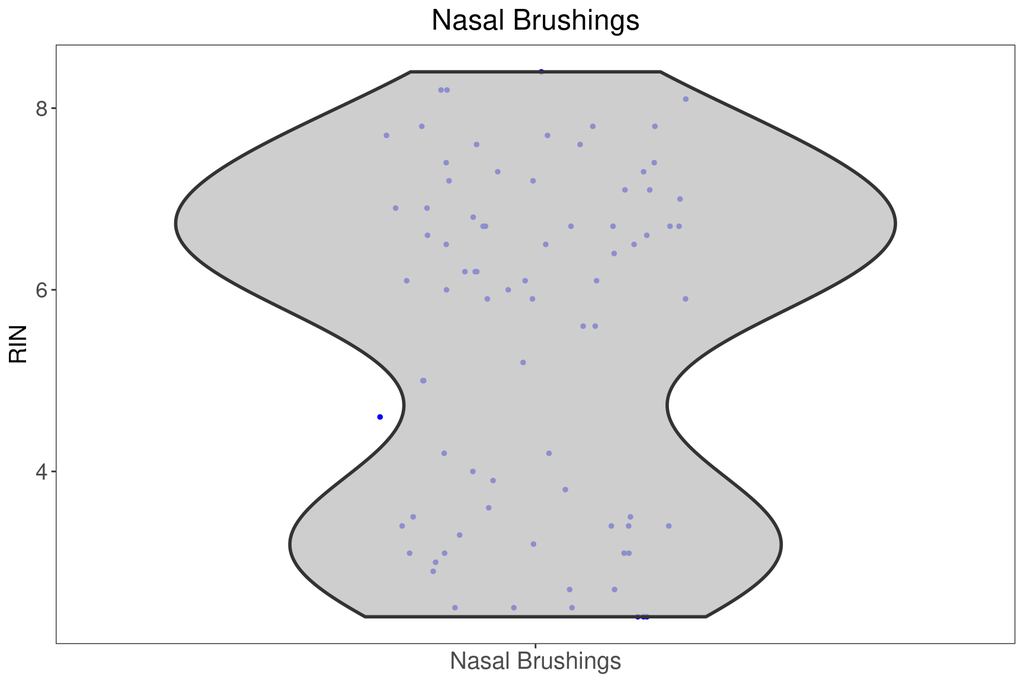

```r
dots <- T
boxplot <- F
violin <- T

df <- data.frame(
  x = annotNasal$`Sample Type`,
  y = annotNasal$RIN
)

p <- ggplot2::ggplot(df) +
  ggplot2::aes_string(
    x = "x",
    y = "y"
  )
if (dots == TRUE) {
  p <- p + ggplot2::geom_jitter(
    color = "blue",
    width = 0.2,
    height = 0,
    size = 1,
    alpha = 1
  )
}
if (boxplot == TRUE) {
  p <- p + ggplot2::geom_boxplot(
    width = 0.5,
    alpha = 0
  )
}
if (violin == TRUE) {
  p <- p + ggplot2::geom_violin(
    trim = TRUE,
    scale = "width",
    size = 1,
    fill = "grey",
    alpha = 0.75
  )
}

p <- p + ggplot2::theme_bw() +
  ggplot2::theme(
    panel.grid.major = ggplot2::element_blank(),
    panel.grid.minor = ggplot2::element_blank(),
    axis.text = ggplot2::element_text(size = 14),
    axis.title = ggplot2::element_text(size = 10)
  ) + ggplot2::theme(axis.text.x = ggplot2::element_text(size = 15)) +
  ggplot2::ylab("RIN") +
  ggplot2::theme(
    axis.title.y = element_text(size = 15),
    axis.title.x = ggplot2::element_blank()
  )

p <- p + ggplot2::ggtitle(label = "Nasal Brushings") +
  ggplot2::theme(plot.title = ggplot2::element_text(
    hjust = 0.5,
    size = 18
  ))

p
```

### Genes detected

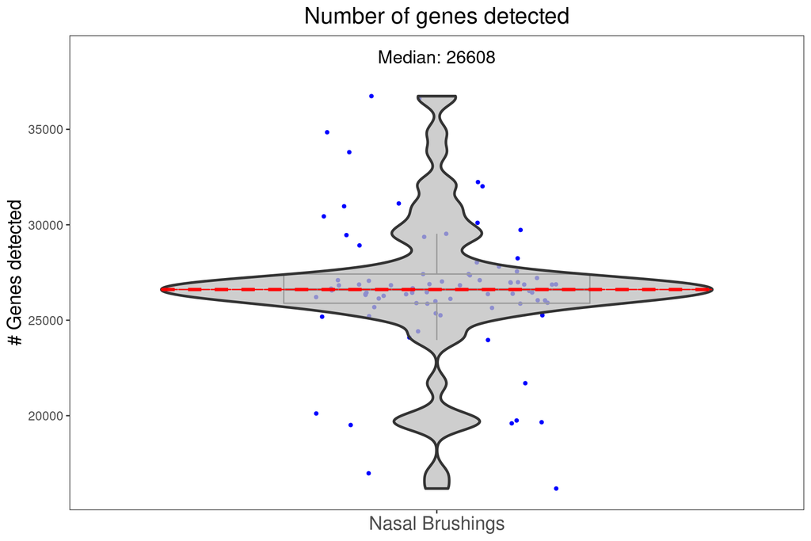

```r
dots <- T
boxplot <- T
violin <- T

df <- data.frame(
  x = annotNasal$`Sample Type`,
  y = colSums(assay(seNasal) > 0)
)

p <- ggplot2::ggplot(df) +
  ggplot2::aes_string(
    x = "x",
    y = "y"
  )
if (dots == TRUE) {
  p <- p + ggplot2::geom_jitter(
    color = "blue",
    width = 0.2,
    height = 0,
    size = 1,
    alpha = 1
  )
}
if (boxplot == TRUE) {
  p <- p + ggplot2::geom_boxplot(
    width = 0.5,
    alpha = 0
  )
}
if (violin == TRUE) {
  p <- p + ggplot2::geom_violin(
    trim = TRUE,
    scale = "width",
    size = 1,
    fill = "grey",
    alpha = 0.75
  )
}

p <- p + ggplot2::theme_bw() +
  ggplot2::theme(
    panel.grid.major = ggplot2::element_blank(),
    panel.grid.minor = ggplot2::element_blank(),
    axis.text = ggplot2::element_text(size = 10),
    axis.title = ggplot2::element_text(size = 10)
  ) + ggplot2::theme(axis.text.x = ggplot2::element_text(size = 15)) +
  ggplot2::ylab("# Genes detected") +
  ggplot2::theme(
    axis.title.y = element_text(size = 15),
    axis.title.x = ggplot2::element_blank()
  )

p <- p + ggplot2::ggtitle(label = "Number of genes detected") +
  ggplot2::theme(plot.title = ggplot2::element_text(
    hjust = 0.5,
    size = 18
  ))
summary <- "median"
summ <- df %>%
  dplyr::group_by(x) %>%
  dplyr::summarize(value = stats::median(y))
fun <- stats::median

summ$statY <- max(df$y) + (max(df$y) - min(df$y)) * 0.1
summary <- paste(toupper(substr(summary, 1, 1)),
  substr(summary, 2, nchar(summary)),
  sep = ""
)
summ$label <- paste0(summary, ": ", round(summ$value, 5))

p <- p + ggplot2::geom_text(
  data = summ,
  ggplot2::aes_string(
    x = "x",
    y = "statY",
    label = "label"
  ),
  size = 5
)
p <- p + ggplot2::stat_summary(
  fun = fun, fun.min = fun,
  fun.max = fun,
  geom = "crossbar",
  color = "red",
  linetype = "dashed"
)
p
```

### Percent GC

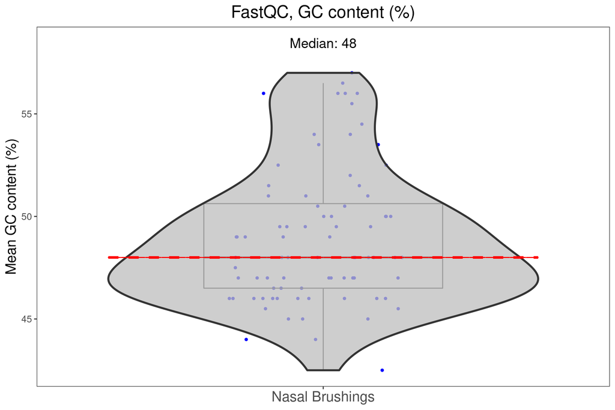

```r
df <- data.frame(
  x = annotNasal$`Sample Type`,
  y = unlist(lapply(coldataNasal$FastQC_percent_GC, FUN = mean))
)

p <- ggplot2::ggplot(df) +
  ggplot2::aes_string(
    x = "x",
    y = "y"
  )
if (dots == TRUE) {
  p <- p + ggplot2::geom_jitter(
    color = "blue",
    width = 0.2,
    height = 0,
    size = 1,
    alpha = 1
  )
}
if (boxplot == TRUE) {
  p <- p + ggplot2::geom_boxplot(
    width = 0.5,
    alpha = 0
  )
}
if (violin == TRUE) {
  p <- p + ggplot2::geom_violin(
    trim = TRUE,
    scale = "width",
    size = 1,
    fill = "grey",
    alpha = 0.75
  )
}

p <- p + ggplot2::theme_bw() +
  ggplot2::theme(
    panel.grid.major = ggplot2::element_blank(),
    panel.grid.minor = ggplot2::element_blank(),
    axis.text = ggplot2::element_text(size = 10),
    axis.title = ggplot2::element_text(size = 10)
  ) + ggplot2::theme(axis.text.x = ggplot2::element_text(size = 15)) +
  ggplot2::ylab("Mean GC content (%)") +
  ggplot2::theme(
    axis.title.y = element_text(size = 15),
    axis.title.x = ggplot2::element_blank()
  )

p <- p + ggplot2::ggtitle(label = "FastQC, GC content (%)") +
  ggplot2::theme(plot.title = ggplot2::element_text(
    hjust = 0.5,
    size = 18
  ))
summary <- "median"
summ <- df %>%
  dplyr::group_by(x) %>%
  dplyr::summarize(value = stats::median(y))
fun <- stats::median

summ$statY <- max(df$y) + (max(df$y) - min(df$y)) * 0.1
summary <- paste(toupper(substr(summary, 1, 1)),
  substr(summary, 2, nchar(summary)),
  sep = ""
)
summ$label <- paste0(summary, ": ", round(summ$value, 5))

p <- p + ggplot2::geom_text(
  data = summ,
  ggplot2::aes_string(
    x = "x",
    y = "statY",
    label = "label"
  ),
  size = 5
)
p <- p + ggplot2::stat_summary(
  fun = fun, fun.min = fun,
  fun.max = fun,
  geom = "crossbar",
  color = "red",
  linetype = "dashed"
)
p
```

### Percent aligned to exons

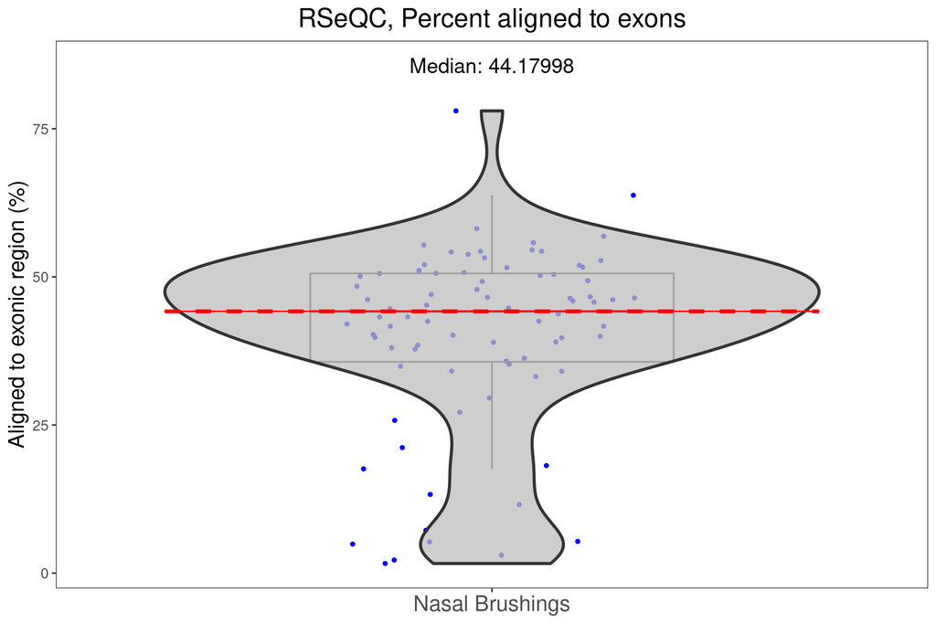

```r
df <- data.frame(
  x = annotNasal$`Sample Type`,
  y = (coldataNasal$RSeQC_cds_exons_tag_pct +
    coldataNasal$RSeQC_3_utr_exons_tag_pct +
    coldataNasal$RSeQC_5_utr_exons_tag_pct)
)

p <- ggplot2::ggplot(df) +
  ggplot2::aes_string(
    x = "x",
    y = "y"
  )
if (dots == TRUE) {
  p <- p + ggplot2::geom_jitter(
    color = "blue",
    width = 0.2,
    height = 0,
    size = 1,
    alpha = 1
  )
}
if (boxplot == TRUE) {
  p <- p + ggplot2::geom_boxplot(
    width = 0.5,
    alpha = 0
  )
}
if (violin == TRUE) {
  p <- p + ggplot2::geom_violin(
    trim = TRUE,
    scale = "width",
    size = 1,
    fill = "grey",
    alpha = 0.75
  )
}

p <- p + ggplot2::theme_bw() +
  ggplot2::theme(
    panel.grid.major = ggplot2::element_blank(),
    panel.grid.minor = ggplot2::element_blank(),
    axis.text = ggplot2::element_text(size = 10),
    axis.title = ggplot2::element_text(size = 10)
  ) + ggplot2::theme(axis.text.x = ggplot2::element_text(size = 15)) +
  ggplot2::ylab("Aligned to exonic region (%)") +
  ggplot2::theme(
    axis.title.y = element_text(size = 15),
    axis.title.x = ggplot2::element_blank()
  )

p <- p + ggplot2::ggtitle(label = "RSeQC, Percent aligned to exons") +
  ggplot2::theme(plot.title = ggplot2::element_text(
    hjust = 0.5,
    size = 18
  ))
summary <- "median"
summ <- df %>%
  dplyr::group_by(x) %>%
  dplyr::summarize(value = stats::median(y))
fun <- stats::median

summ$statY <- max(df$y) + (max(df$y) - min(df$y)) * 0.1
summary <- paste(toupper(substr(summary, 1, 1)),
  substr(summary, 2, nchar(summary)),
  sep = ""
)
summ$label <- paste0(summary, ": ", round(summ$value, 5))

p <- p + ggplot2::geom_text(
  data = summ,
  ggplot2::aes_string(
    x = "x",
    y = "statY",
    label = "label"
  ),
  size = 5
)
p <- p + ggplot2::stat_summary(
  fun = fun, fun.min = fun,
  fun.max = fun,
  geom = "crossbar",
  color = "red",
  linetype = "dashed"
)
p
```

### Percent aligned to introns

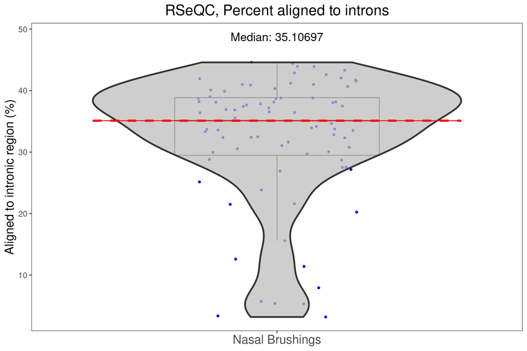

```r
df <- data.frame(
  x = annotNasal$`Sample Type`,
  y = coldataNasal$RSeQC_introns_tag_pct
)

p <- ggplot2::ggplot(df) +
  ggplot2::aes_string(
    x = "x",
    y = "y"
  )
if (dots == TRUE) {
  p <- p + ggplot2::geom_jitter(
    color = "blue",
    width = 0.2,
    height = 0,
    size = 1,
    alpha = 1
  )
}
if (boxplot == TRUE) {
  p <- p + ggplot2::geom_boxplot(
    width = 0.5,
    alpha = 0
  )
}
if (violin == TRUE) {
  p <- p + ggplot2::geom_violin(
    trim = TRUE,
    scale = "width",
    size = 1,
    fill = "grey",
    alpha = 0.75
  )
}

p <- p + ggplot2::theme_bw() +
  ggplot2::theme(
    panel.grid.major = ggplot2::element_blank(),
    panel.grid.minor = ggplot2::element_blank(),
    axis.text = ggplot2::element_text(size = 10),
    axis.title = ggplot2::element_text(size = 10)
  ) + ggplot2::theme(axis.text.x = ggplot2::element_text(size = 15)) +
  ggplot2::ylab("Aligned to intronic region (%)") +
  ggplot2::theme(
    axis.title.y = element_text(size = 15),
    axis.title.x = ggplot2::element_blank()
  )

p <- p + ggplot2::ggtitle(label = "RSeQC, Percent aligned to introns") +
  ggplot2::theme(plot.title = ggplot2::element_text(
    hjust = 0.5,
    size = 18
  ))
summary <- "median"
summ <- df %>%
  dplyr::group_by(x) %>%
  dplyr::summarize(value = stats::median(y))
fun <- stats::median

summ$statY <- max(df$y) + (max(df$y) - min(df$y)) * 0.1
summary <- paste(toupper(substr(summary, 1, 1)),
  substr(summary, 2, nchar(summary)),
  sep = ""
)
summ$label <- paste0(summary, ": ", round(summ$value, 5))

p <- p + ggplot2::geom_text(
  data = summ,
  ggplot2::aes_string(
    x = "x",
    y = "statY",
    label = "label"
  ),
  size = 5
)
p <- p + ggplot2::stat_summary(
  fun = fun, fun.min = fun,
  fun.max = fun,
  geom = "crossbar",
  color = "red",
  linetype = "dashed"
)
p
```

### Percent aligned to intergenic regions

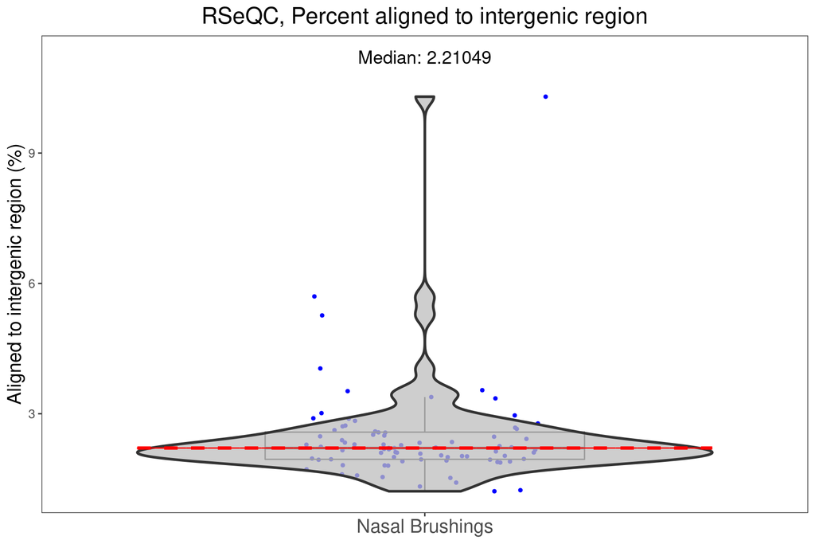

```r
df <- data.frame(
  x = annotNasal$`Sample Type`,
  y = coldataNasal$RSeQC_tes_down_10kb_tag_pct +
    coldataNasal$RSeQC_tss_up_10kb_tag_pct
)

p <- ggplot2::ggplot(df) +
  ggplot2::aes_string(
    x = "x",
    y = "y"
  )
if (dots == TRUE) {
  p <- p + ggplot2::geom_jitter(
    color = "blue",
    width = 0.2,
    height = 0,
    size = 1,
    alpha = 1
  )
}
if (boxplot == TRUE) {
  p <- p + ggplot2::geom_boxplot(
    width = 0.5,
    alpha = 0
  )
}
if (violin == TRUE) {
  p <- p + ggplot2::geom_violin(
    trim = TRUE,
    scale = "width",
    size = 1,
    fill = "grey",
    alpha = 0.75
  )
}

p <- p + ggplot2::theme_bw() +
  ggplot2::theme(
    panel.grid.major = ggplot2::element_blank(),
    panel.grid.minor = ggplot2::element_blank(),
    axis.text = ggplot2::element_text(size = 10),
    axis.title = ggplot2::element_text(size = 10)
  ) + ggplot2::theme(axis.text.x = ggplot2::element_text(size = 15)) +
  ggplot2::ylab("Aligned to intergenic region (%)") +
  ggplot2::theme(
    axis.title.y = element_text(size = 15),
    axis.title.x = ggplot2::element_blank()
  )

p <- p + ggplot2::ggtitle(label = "RSeQC, Percent aligned to intergenic region") +
  ggplot2::theme(plot.title = ggplot2::element_text(
    hjust = 0.5,
    size = 18
  ))
summary <- "median"
summ <- df %>%
  dplyr::group_by(x) %>%
  dplyr::summarize(value = stats::median(y))
fun <- stats::median

summ$statY <- max(df$y) + (max(df$y) - min(df$y)) * 0.1
summary <- paste(toupper(substr(summary, 1, 1)),
  substr(summary, 2, nchar(summary)),
  sep = ""
)
summ$label <- paste0(summary, ": ", round(summ$value, 5))

p <- p + ggplot2::geom_text(
  data = summ,
  ggplot2::aes_string(
    x = "x",
    y = "statY",
    label = "label"
  ),
  size = 5
)
p <- p + ggplot2::stat_summary(
  fun = fun, fun.min = fun,
  fun.max = fun,
  geom = "crossbar",
  color = "red",
  linetype = "dashed"
)
p
```

Includes regions upstream of TSS (<10kb) and downstream of TES (<10kb)

### Strandedness - Sense

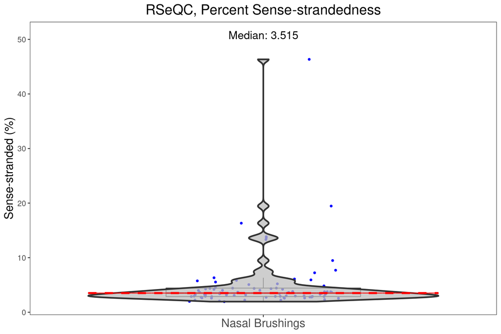

```r
df <- data.frame(
  x = annotNasal$`Sample Type`,
  y = coldataNasal$RSeQC_pe_sense * 100
)

p <- ggplot2::ggplot(df) +
  ggplot2::aes_string(
    x = "x",
    y = "y"
  )
if (dots == TRUE) {
  p <- p + ggplot2::geom_jitter(
    color = "blue",
    width = 0.2,
    height = 0,
    size = 1,
    alpha = 1
  )
}
if (boxplot == TRUE) {
  p <- p + ggplot2::geom_boxplot(
    width = 0.5,
    alpha = 0
  )
}
if (violin == TRUE) {
  p <- p + ggplot2::geom_violin(
    trim = TRUE,
    scale = "width",
    size = 1,
    fill = "grey",
    alpha = 0.75
  )
}

p <- p + ggplot2::theme_bw() +
  ggplot2::theme(
    panel.grid.major = ggplot2::element_blank(),
    panel.grid.minor = ggplot2::element_blank(),
    axis.text = ggplot2::element_text(size = 10),
    axis.title = ggplot2::element_text(size = 10)
  ) + ggplot2::theme(axis.text.x = ggplot2::element_text(size = 15)) +
  ggplot2::ylab("Sense-stranded (%)") +
  ggplot2::theme(
    axis.title.y = element_text(size = 15),
    axis.title.x = ggplot2::element_blank()
  )

p <- p + ggplot2::ggtitle(label = "RSeQC, Percent Sense-strandedness") +
  ggplot2::theme(plot.title = ggplot2::element_text(
    hjust = 0.5,
    size = 18
  ))
summary <- "median"
summ <- df %>%
  dplyr::group_by(x) %>%
  dplyr::summarize(value = stats::median(y))
fun <- stats::median

summ$statY <- max(df$y) + (max(df$y) - min(df$y)) * 0.1
summary <- paste(toupper(substr(summary, 1, 1)),
  substr(summary, 2, nchar(summary)),
  sep = ""
)
summ$label <- paste0(summary, ": ", round(summ$value, 5))

p <- p + ggplot2::geom_text(
  data = summ,
  ggplot2::aes_string(
    x = "x",
    y = "statY",
    label = "label"
  ),
  size = 5
)
p <- p + ggplot2::stat_summary(
  fun = fun, fun.min = fun,
  fun.max = fun,
  geom = "crossbar",
  color = "red",
  linetype = "dashed"
)
p
```

### Strandedness - Antisense

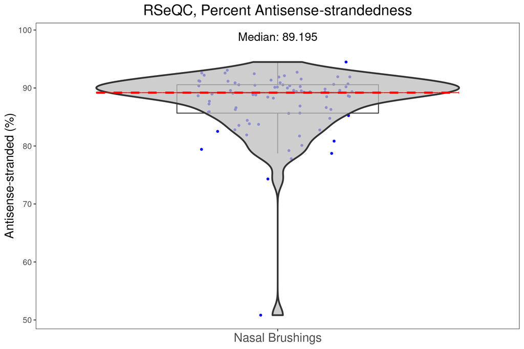

```r
df <- data.frame(
  x = annotNasal$`Sample Type`,
  y = coldataNasal$RSeQC_pe_antisense * 100
)

p <- ggplot2::ggplot(df) +
  ggplot2::aes_string(
    x = "x",
    y = "y"
  )
if (dots == TRUE) {
  p <- p + ggplot2::geom_jitter(
    color = "blue",
    width = 0.2,
    height = 0,
    size = 1,
    alpha = 1
  )
}
if (boxplot == TRUE) {
  p <- p + ggplot2::geom_boxplot(
    width = 0.5,
    alpha = 0
  )
}
if (violin == TRUE) {
  p <- p + ggplot2::geom_violin(
    trim = TRUE,
    scale = "width",
    size = 1,
    fill = "grey",
    alpha = 0.75
  )
}

p <- p + ggplot2::theme_bw() +
  ggplot2::theme(
    panel.grid.major = ggplot2::element_blank(),
    panel.grid.minor = ggplot2::element_blank(),
    axis.text = ggplot2::element_text(size = 10),
    axis.title = ggplot2::element_text(size = 10)
  ) + ggplot2::theme(axis.text.x = ggplot2::element_text(size = 15)) +
  ggplot2::ylab("Antisense-stranded (%)") +
  ggplot2::theme(
    axis.title.y = element_text(size = 15),
    axis.title.x = ggplot2::element_blank()
  )

p <- p + ggplot2::ggtitle(label = "RSeQC, Percent Antisense-strandedness") +
  ggplot2::theme(plot.title = ggplot2::element_text(
    hjust = 0.5,
    size = 18
  ))
summary <- "median"
summ <- df %>%
  dplyr::group_by(x) %>%
  dplyr::summarize(value = stats::median(y))
fun <- stats::median

summ$statY <- max(df$y) + (max(df$y) - min(df$y)) * 0.1
summary <- paste(toupper(substr(summary, 1, 1)),
  substr(summary, 2, nchar(summary)),
  sep = ""
)
summ$label <- paste0(summary, ": ", round(summ$value, 5))

p <- p + ggplot2::geom_text(
  data = summ,
  ggplot2::aes_string(
    x = "x",
    y = "statY",
    label = "label"
  ),
  size = 5
)
p <- p + ggplot2::stat_summary(
  fun = fun, fun.min = fun,
  fun.max = fun,
  geom = "crossbar",
  color = "red",
  linetype = "dashed"
)
p
```

### Proper Pair Percentage

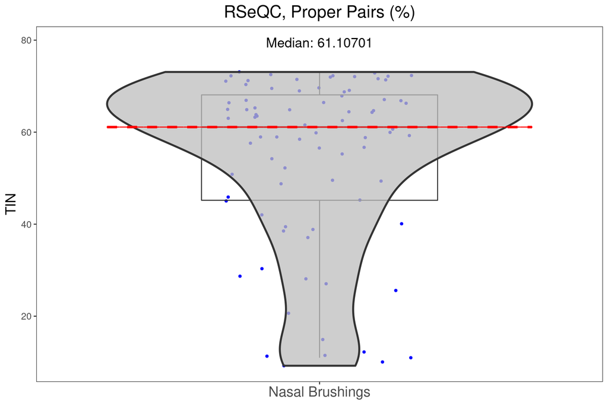

```r
df <- data.frame(
  x = annotNasal$`Sample Type`,
  y = coldataNasal$RSeQC_proper_pairs_percent
)

p <- ggplot2::ggplot(df) +
  ggplot2::aes_string(
    x = "x",
    y = "y"
  )
if (dots == TRUE) {
  p <- p + ggplot2::geom_jitter(
    color = "blue",
    width = 0.2,
    height = 0,
    size = 1,
    alpha = 1
  )
}
if (boxplot == TRUE) {
  p <- p + ggplot2::geom_boxplot(
    width = 0.5,
    alpha = 0
  )
}
if (violin == TRUE) {
  p <- p + ggplot2::geom_violin(
    trim = TRUE,
    scale = "width",
    size = 1,
    fill = "grey",
    alpha = 0.75
  )
}

p <- p + ggplot2::theme_bw() +
  ggplot2::theme(
    panel.grid.major = ggplot2::element_blank(),
    panel.grid.minor = ggplot2::element_blank(),
    axis.text = ggplot2::element_text(size = 10),
    axis.title = ggplot2::element_text(size = 10)
  ) + ggplot2::theme(axis.text.x = ggplot2::element_text(size = 15)) +
  ggplot2::ylab("TIN") +
  ggplot2::theme(
    axis.title.y = element_text(size = 15),
    axis.title.x = ggplot2::element_blank()
  )

p <- p + ggplot2::ggtitle(label = "RSeQC, Proper Pairs (%)") +
  ggplot2::theme(plot.title = ggplot2::element_text(
    hjust = 0.5,
    size = 18
  ))
summary <- "median"
summ <- df %>%
  dplyr::group_by(x) %>%
  dplyr::summarize(value = stats::median(y))
fun <- stats::median

summ$statY <- max(df$y) + (max(df$y) - min(df$y)) * 0.1
summary <- paste(toupper(substr(summary, 1, 1)),
  substr(summary, 2, nchar(summary)),
  sep = ""
)
summ$label <- paste0(summary, ": ", round(summ$value, 5))

p <- p + ggplot2::geom_text(
  data = summ,
  ggplot2::aes_string(
    x = "x",
    y = "statY",
    label = "label"
  ),
  size = 5
)
p <- p + ggplot2::stat_summary(
  fun = fun, fun.min = fun,
  fun.max = fun,
  geom = "crossbar",
  color = "red",
  linetype = "dashed"
)
p
```

### TIN

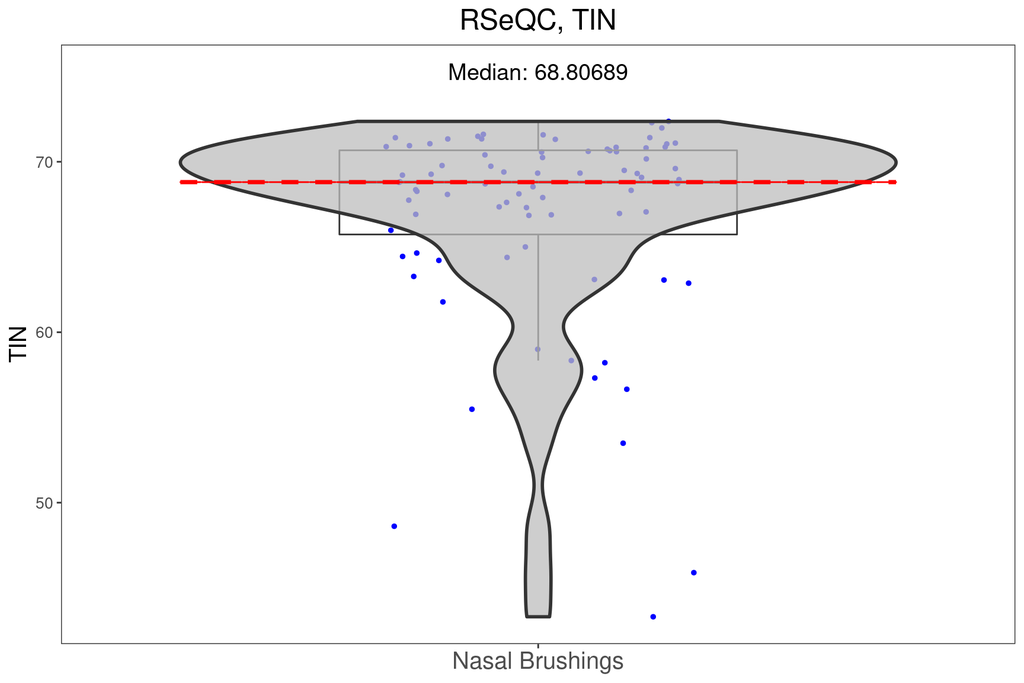

```r
df <- data.frame(
  x = annotNasal$`Sample Type`,
  y = coldataNasal$RSeQC_TIN_mean
)

p <- ggplot2::ggplot(df) +
  ggplot2::aes_string(
    x = "x",
    y = "y"
  )
if (dots == TRUE) {
  p <- p + ggplot2::geom_jitter(
    color = "blue",
    width = 0.2,
    height = 0,
    size = 1,
    alpha = 1
  )
}
if (boxplot == TRUE) {
  p <- p + ggplot2::geom_boxplot(
    width = 0.5,
    alpha = 0
  )
}
if (violin == TRUE) {
  p <- p + ggplot2::geom_violin(
    trim = TRUE,
    scale = "width",
    size = 1,
    fill = "grey",
    alpha = 0.75
  )
}

p <- p + ggplot2::theme_bw() +
  ggplot2::theme(
    panel.grid.major = ggplot2::element_blank(),
    panel.grid.minor = ggplot2::element_blank(),
    axis.text = ggplot2::element_text(size = 10),
    axis.title = ggplot2::element_text(size = 10)
  ) + ggplot2::theme(axis.text.x = ggplot2::element_text(size = 15)) +
  ggplot2::ylab("TIN") +
  ggplot2::theme(
    axis.title.y = element_text(size = 15),
    axis.title.x = ggplot2::element_blank()
  )

p <- p + ggplot2::ggtitle(label = "RSeQC, TIN") +
  ggplot2::theme(plot.title = ggplot2::element_text(
    hjust = 0.5,
    size = 18
  ))
summary <- "median"
summ <- df %>%
  dplyr::group_by(x) %>%
  dplyr::summarize(value = stats::median(y))
fun <- stats::median

summ$statY <- max(df$y) + (max(df$y) - min(df$y)) * 0.1
summary <- paste(toupper(substr(summary, 1, 1)),
  substr(summary, 2, nchar(summary)),
  sep = ""
)
summ$label <- paste0(summary, ": ", round(summ$value, 5))

p <- p + ggplot2::geom_text(
  data = summ,
  ggplot2::aes_string(
    x = "x",
    y = "statY",
    label = "label"
  ),
  size = 5
)
p <- p + ggplot2::stat_summary(
  fun = fun, fun.min = fun,
  fun.max = fun,
  geom = "crossbar",
  color = "red",
  linetype = "dashed"
)
p
```

### Percentage reads uniquely mapped

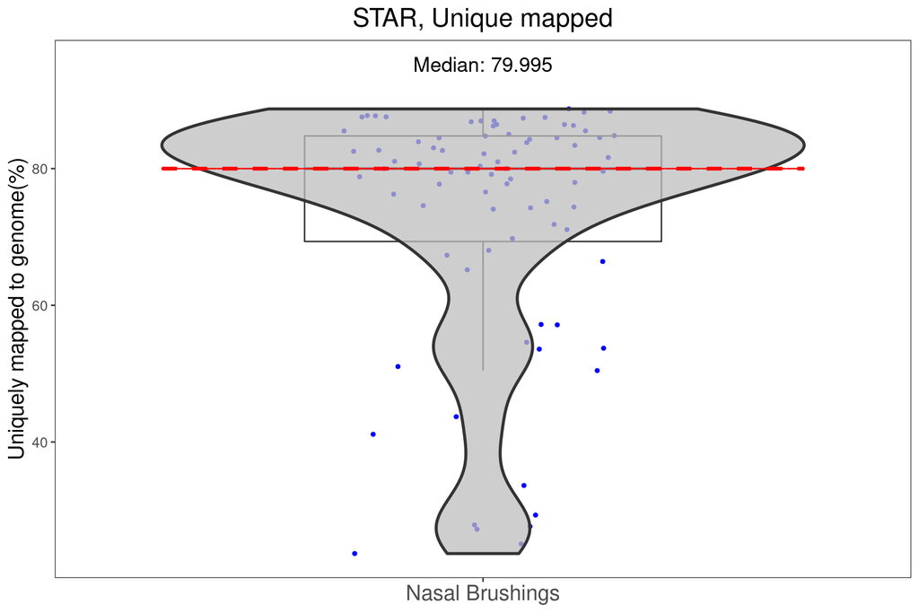

```r
df <- data.frame(
  x = annotNasal$`Sample Type`,
  y = coldataNasal$STAR_uniquely_mapped_percent
)

p <- ggplot2::ggplot(df) +
  ggplot2::aes_string(
    x = "x",
    y = "y"
  )
if (dots == TRUE) {
  p <- p + ggplot2::geom_jitter(
    color = "blue",
    width = 0.2,
    height = 0,
    size = 1,
    alpha = 1
  )
}
if (boxplot == TRUE) {
  p <- p + ggplot2::geom_boxplot(
    width = 0.5,
    alpha = 0
  )
}
if (violin == TRUE) {
  p <- p + ggplot2::geom_violin(
    trim = TRUE,
    scale = "width",
    size = 1,
    fill = "grey",
    alpha = 0.75
  )
}

p <- p + ggplot2::theme_bw() +
  ggplot2::theme(
    panel.grid.major = ggplot2::element_blank(),
    panel.grid.minor = ggplot2::element_blank(),
    axis.text = ggplot2::element_text(size = 10),
    axis.title = ggplot2::element_text(size = 10)
  ) + ggplot2::theme(axis.text.x = ggplot2::element_text(size = 15)) +
  ggplot2::ylab("Uniquely mapped to genome(%)") +
  ggplot2::theme(
    axis.title.y = element_text(size = 15),
    axis.title.x = ggplot2::element_blank()
  )

p <- p + ggplot2::ggtitle(label = "STAR, Unique mapped") +
  ggplot2::theme(plot.title = ggplot2::element_text(
    hjust = 0.5,
    size = 18
  ))
summary <- "median"
summ <- df %>%
  dplyr::group_by(x) %>%
  dplyr::summarize(value = stats::median(y))
fun <- stats::median

summ$statY <- max(df$y) + (max(df$y) - min(df$y)) * 0.1
summary <- paste(toupper(substr(summary, 1, 1)),
  substr(summary, 2, nchar(summary)),
  sep = ""
)
summ$label <- paste0(summary, ": ", round(summ$value, 5))

p <- p + ggplot2::geom_text(
  data = summ,
  ggplot2::aes_string(
    x = "x",
    y = "statY",
    label = "label"
  ),
  size = 5
)
p <- p + ggplot2::stat_summary(
  fun = fun, fun.min = fun,
  fun.max = fun,
  geom = "crossbar",
  color = "red",
  linetype = "dashed"
)
p
```

### Percentage reads unmapped

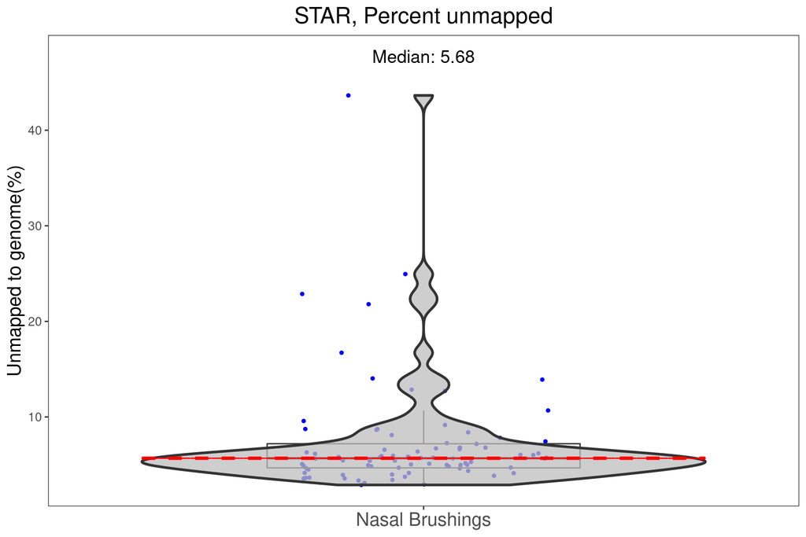

```r
df <- data.frame(
  x = annotNasal$`Sample Type`,
  y = coldataNasal$STAR_unmapped_mismatches_percent +
    coldataNasal$STAR_unmapped_tooshort_percent +
    coldataNasal$STAR_unmapped_other_percent
)

p <- ggplot2::ggplot(df) +
  ggplot2::aes_string(
    x = "x",
    y = "y"
  )
if (dots == TRUE) {
  p <- p + ggplot2::geom_jitter(
    color = "blue",
    width = 0.2,
    height = 0,
    size = 1,
    alpha = 1
  )
}
if (boxplot == TRUE) {
  p <- p + ggplot2::geom_boxplot(
    width = 0.5,
    alpha = 0
  )
}
if (violin == TRUE) {
  p <- p + ggplot2::geom_violin(
    trim = TRUE,
    scale = "width",
    size = 1,
    fill = "grey",
    alpha = 0.75
  )
}

p <- p + ggplot2::theme_bw() +
  ggplot2::theme(
    panel.grid.major = ggplot2::element_blank(),
    panel.grid.minor = ggplot2::element_blank(),
    axis.text = ggplot2::element_text(size = 10),
    axis.title = ggplot2::element_text(size = 10)
  ) + ggplot2::theme(axis.text.x = ggplot2::element_text(size = 15)) +
  ggplot2::ylab("Unmapped to genome(%)") +
  ggplot2::theme(
    axis.title.y = element_text(size = 15),
    axis.title.x = ggplot2::element_blank()
  )

p <- p + ggplot2::ggtitle(label = "STAR, Percent unmapped") +
  ggplot2::theme(plot.title = ggplot2::element_text(
    hjust = 0.5,
    size = 18
  ))
summary <- "median"
summ <- df %>%
  dplyr::group_by(x) %>%
  dplyr::summarize(value = stats::median(y))
fun <- stats::median

summ$statY <- max(df$y) + (max(df$y) - min(df$y)) * 0.1
summary <- paste(toupper(substr(summary, 1, 1)),
  substr(summary, 2, nchar(summary)),
  sep = ""
)
summ$label <- paste0(summary, ": ", round(summ$value, 5))

p <- p + ggplot2::geom_text(
  data = summ,
  ggplot2::aes_string(
    x = "x",
    y = "statY",
    label = "label"
  ),
  size = 5
)
p <- p + ggplot2::stat_summary(
  fun = fun, fun.min = fun,
  fun.max = fun,
  geom = "crossbar",
  color = "red",
  linetype = "dashed"
)
p
```

### Total reads

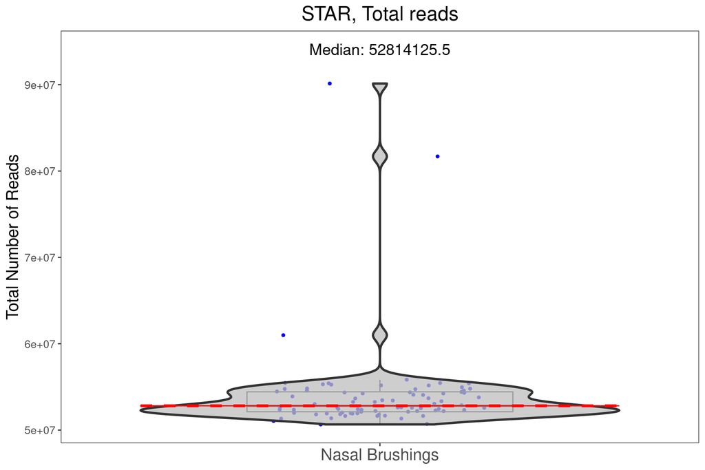

```r
df <- data.frame(
  x = annotNasal$`Sample Type`,
  y = coldataNasal$STAR_total_reads
)

p <- ggplot2::ggplot(df) +
  ggplot2::aes_string(
    x = "x",
    y = "y"
  )
if (dots == TRUE) {
  p <- p + ggplot2::geom_jitter(
    color = "blue",
    width = 0.2,
    height = 0,
    size = 1,
    alpha = 1
  )
}
if (boxplot == TRUE) {
  p <- p + ggplot2::geom_boxplot(
    width = 0.5,
    alpha = 0
  )
}
if (violin == TRUE) {
  p <- p + ggplot2::geom_violin(
    trim = TRUE,
    scale = "width",
    size = 1,
    fill = "grey",
    alpha = 0.75
  )
}

p <- p + ggplot2::theme_bw() +
  ggplot2::theme(
    panel.grid.major = ggplot2::element_blank(),
    panel.grid.minor = ggplot2::element_blank(),
    axis.text = ggplot2::element_text(size = 10),
    axis.title = ggplot2::element_text(size = 10)
  ) + ggplot2::theme(axis.text.x = ggplot2::element_text(size = 15)) +
  ggplot2::ylab("Total Number of Reads") +
  ggplot2::theme(
    axis.title.y = element_text(size = 15),
    axis.title.x = ggplot2::element_blank()
  )

p <- p + ggplot2::ggtitle(label = "STAR, Total reads") +
  ggplot2::theme(plot.title = ggplot2::element_text(
    hjust = 0.5,
    size = 18
  ))
summary <- "median"
summ <- df %>%
  dplyr::group_by(x) %>%
  dplyr::summarize(value = stats::median(y))
fun <- stats::median

summ$statY <- max(df$y) + (max(df$y) - min(df$y)) * 0.1
summary <- paste(toupper(substr(summary, 1, 1)),
  substr(summary, 2, nchar(summary)),
  sep = ""
)
summ$label <- paste0(summary, ": ", round(summ$value, 5))

p <- p + ggplot2::geom_text(
  data = summ,
  ggplot2::aes_string(
    x = "x",
    y = "statY",
    label = "label"
  ),
  size = 5
)
p <- p + ggplot2::stat_summary(
  fun = fun, fun.min = fun,
  fun.max = fun,
  geom = "crossbar",
  color = "red",
  linetype = "dashed"
)
p
```

### Mismatch rate

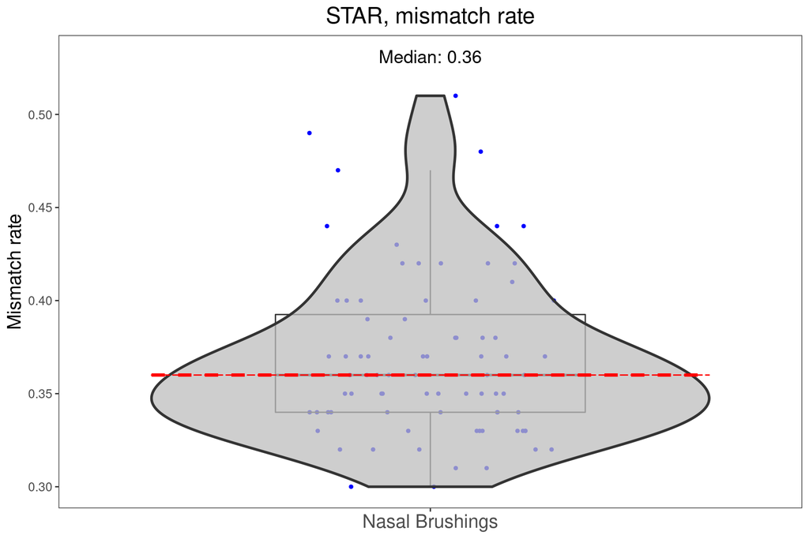

```r
df <- data.frame(
  x = annotNasal$`Sample Type`,
  y = coldataNasal$STAR_mismatch_rate
)

p <- ggplot2::ggplot(df) +
  ggplot2::aes_string(
    x = "x",
    y = "y"
  )
if (dots == TRUE) {
  p <- p + ggplot2::geom_jitter(
    color = "blue",
    width = 0.2,
    height = 0,
    size = 1,
    alpha = 1
  )
}
if (boxplot == TRUE) {
  p <- p + ggplot2::geom_boxplot(
    width = 0.5,
    alpha = 0
  )
}
if (violin == TRUE) {
  p <- p + ggplot2::geom_violin(
    trim = TRUE,
    scale = "width",
    size = 1,
    fill = "grey",
    alpha = 0.75
  )
}

p <- p + ggplot2::theme_bw() +
  ggplot2::theme(
    panel.grid.major = ggplot2::element_blank(),
    panel.grid.minor = ggplot2::element_blank(),
    axis.text = ggplot2::element_text(size = 10),
    axis.title = ggplot2::element_text(size = 10)
  ) + ggplot2::theme(axis.text.x = ggplot2::element_text(size = 15)) +
  ggplot2::ylab("Mismatch rate") +
  ggplot2::theme(
    axis.title.y = element_text(size = 15),
    axis.title.x = ggplot2::element_blank()
  )

p <- p + ggplot2::ggtitle(label = "STAR, mismatch rate") +
  ggplot2::theme(plot.title = ggplot2::element_text(
    hjust = 0.5,
    size = 18
  ))
summary <- "median"
summ <- df %>%
  dplyr::group_by(x) %>%
  dplyr::summarize(value = stats::median(y))
fun <- stats::median

summ$statY <- max(df$y) + (max(df$y) - min(df$y)) * 0.1
summary <- paste(toupper(substr(summary, 1, 1)),
  substr(summary, 2, nchar(summary)),
  sep = ""
)
summ$label <- paste0(summary, ": ", round(summ$value, 5))

p <- p + ggplot2::geom_text(
  data = summ,
  ggplot2::aes_string(
    x = "x",
    y = "statY",
    label = "label"
  ),
  size = 5
)
p <- p + ggplot2::stat_summary(
  fun = fun, fun.min = fun,
  fun.max = fun,
  geom = "crossbar",
  color = "red",
  linetype = "dashed"
)
p
```

## Histogram, QC outliers

A tally of how many times a sample had an outlier for a numeric QC output was taken. An outlier was considered to be a value past 2 standard deviations of the mean. The barplot below is colored by whether the sample RIN was higher or lower than 5, to determine if RIN scores had a correlation to the QC results.

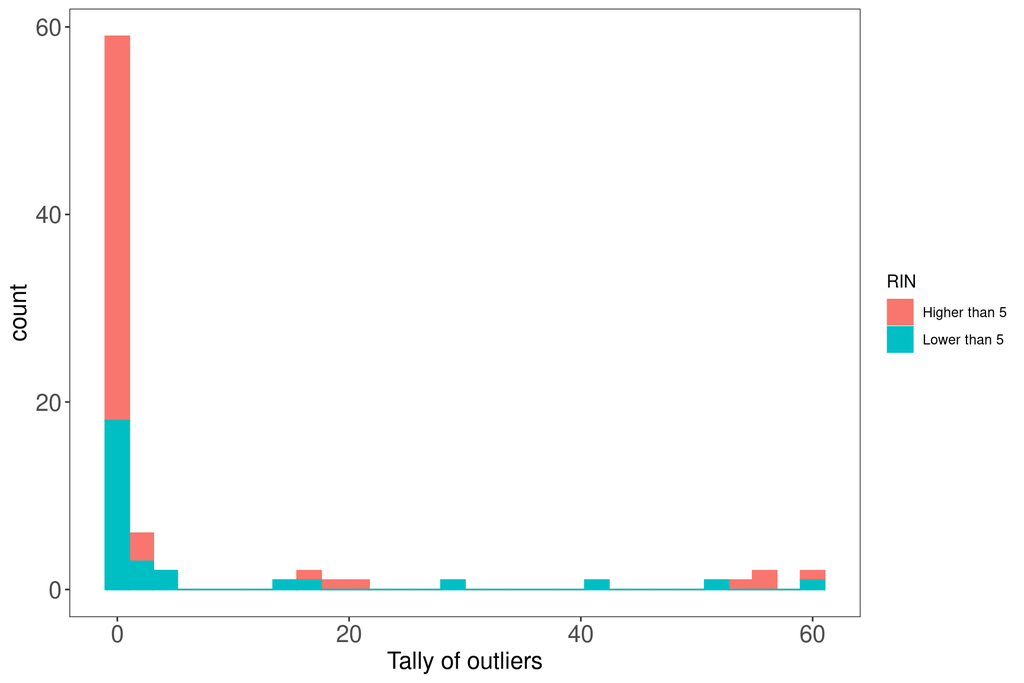

```r
fastqc.ix <- grep("FastQC", colnames(coldataNasal))
rseqc.ix <- grep("RSeQC", colnames(coldataNasal))
star.ix <- grep("STAR", colnames(coldataNasal))

colDataNasalSubset <- coldataNasal[, c(fastqc.ix, rseqc.ix, star.ix)]

# Nasal samples flagged by Novartis
flaggedByNovartisNasal <- flaggedByNovartis[flaggedByNovartis %in% rownames(colDataNasalSubset)]
novartisQC <- sapply(rownames(colDataNasalSubset), function(x) {
  if (x %in% flaggedByNovartisNasal) {
    return("Poor")
  } else {
    return("Good")
  }
})

# FastQC outputs lists instead of numeric/integer, because it is looking
# at pairs of fastqs.
classlist <- c()
for (x in 1:ncol(colDataNasalSubset)) {
  classlist <- c(classlist, class(colDataNasalSubset[1, x]))
}

# Of FastQC outputs, only taking out average seq length, total sequences,
# dedup percentage, percentGC. Other metrics seem to be passing for all data points
colDataNasalSubsetFastq <- colDataNasalSubset[, c(4, 12, 16, 17)]
colDataNasalSubsetFastq2 <- apply(colDataNasalSubsetFastq, 1:2, function(x) {
  return(mean(unlist(x)))
})
colDataNasalSubset <- colDataNasalSubset[, -which(classlist == "list")]
colDataNasalSubset <- cbind(colDataNasalSubset, colDataNasalSubsetFastq2)

# Also removing all QC metrics which have the same values across all samples
rm.ix.qc <- c()
for (x in 1:ncol(colDataNasalSubset)) {
  if (length(unique(colDataNasalSubset[, x])) == 1) {
    rm.ix.qc <- c(rm.ix.qc, x)
  }
}

colDataNasalSubset <- colDataNasalSubset[, -rm.ix.qc]

qc.tally <- matrix(ncol = nrow(colDataNasalSubset), data = 0)
colnames(qc.tally) <- rownames(colDataNasalSubset)

qc.tally2 <- matrix(
  ncol = nrow(colDataNasalSubset),
  nrow = ncol(colDataNasalSubset),
  data = 0
)

rownames(qc.tally2) <- colnames(colDataNasalSubset)
colnames(qc.tally2) <- rownames(colDataNasalSubset)

isNumeric <- 0
for (i in 1:ncol(colDataNasalSubset)) {
  qc <- colDataNasalSubset[, i]
  if (class(qc) == "numeric" | class(qc) == "integer") {
    isNumeric <- isNumeric + 1
    qc.filt <- qc[!is.na(qc)]
    mean.qc <- mean(qc.filt)
    sd.qc <- sd(qc.filt)
    qc.tally[, which(qc > mean.qc + 2 * sd.qc | qc < mean.qc - 2 * sd.qc)] <- qc.tally[, which(qc > mean.qc + 2 * sd.qc | qc < mean.qc - 2 * sd.qc)] + 1

    qc.tally2[i, which(qc > mean.qc + 2 * sd.qc | qc < mean.qc - 2 * sd.qc)] <- qc.tally2[i, which(qc > mean.qc + 2 * sd.qc | qc < mean.qc - 2 * sd.qc)] + 1
  }
}

qc.tally.gg <- as.data.frame(t(qc.tally))
qc.tally.gg$RIN <- annotNasal$RIN < 5
qc.tally.gg$RIN[qc.tally.gg$RIN == TRUE] <- "Lower than 5"
qc.tally.gg$RIN[qc.tally.gg$RIN == FALSE] <- "Higher than 5"

histQC <- ggplot(data = qc.tally.gg, aes(x = V1, color = RIN, fill = RIN)) +
  geom_histogram() +
  labs(x = "Tally of outliers") +
  ggplot2::theme_bw() +
  ggplot2::theme(
    panel.grid.major = ggplot2::element_blank(),
    panel.grid.minor = ggplot2::element_blank(),
    axis.text = ggplot2::element_text(size = 15),
    axis.title = ggplot2::element_text(size = 15)
  )

histQC
```

```r
qc.tally.gg$Number_Outliers_Binned <- qc.tally.gg$V1 > 30

qc.tally.gg$Number_Outliers_Binned <- as.character(qc.tally.gg$Number_Outliers_Binned)
qc.tally.gg$Number_Outliers_Binned <- gsub("FALSE", "x < 25",
                                           qc.tally.gg$Number_Outliers_Binned)
qc.tally.gg$Number_Outliers_Binned <- gsub("TRUE", "x => 25",
                                           qc.tally.gg$Number_Outliers_Binned)

highAmountOutlier <- colnames(qc.tally)[which(qc.tally > 10)]

qualAnnot <- sapply(qc.tally, function(x) {
  if (x < 10) {
    return("x =< 10")
  } else if (x < 25) {
    return("10 < x < 25")
  } else {
    return("x => 25")
  }
})

Number_Outliers_Binned <- as.factor(qualAnnot)
Number_Outliers_Binned <- factor(Number_Outliers_Binned, levels = c("x =< 10",
                                    "10 < x < 25",
                                    "x => 25"))
```

A total of 96 QC metrics were taken into consideration. The following samples had a high number of QC metrics outliers: EM15-1, EM15-31, EM15-54, EM15-64, EM15-85, EM16-194, EM16-228, N1-139, N1-155, N1-160, N2-18, N2-22, N2-28.

The barplots were also annotated by the QC distinctions Novartis had previously made. (Poor vs Good)

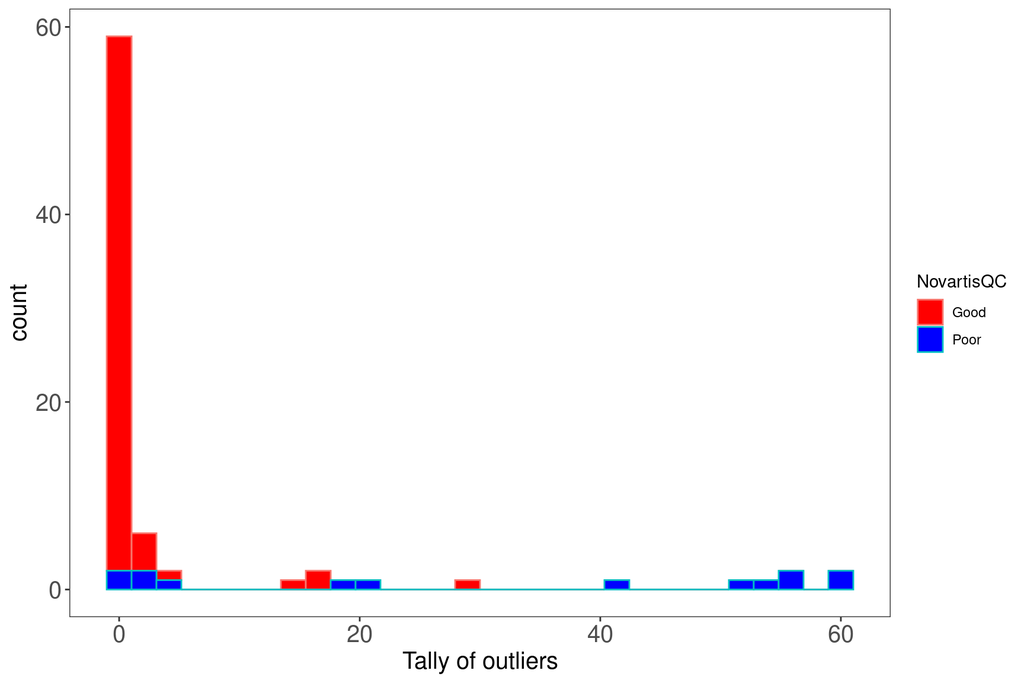

```r
qc.tally.gg$NovartisQC <- novartisQC
histQC2 <- ggplot(data = qc.tally.gg, aes(x = V1, color = NovartisQC, fill = NovartisQC)) +
  geom_histogram() +
  labs(x = "Tally of outliers") +
  ggplot2::theme_bw() +
  ggplot2::theme(
    panel.grid.major = ggplot2::element_blank(),
    panel.grid.minor = ggplot2::element_blank(),
    axis.text = ggplot2::element_text(size = 15),
    axis.title = ggplot2::element_text(size = 15)
  ) +
  scale_fill_manual(values = c("Red", "Blue"))

histQC2
```

## Using Proper pairs percent

### Uniquely mapped vs Proper Pairs Percent

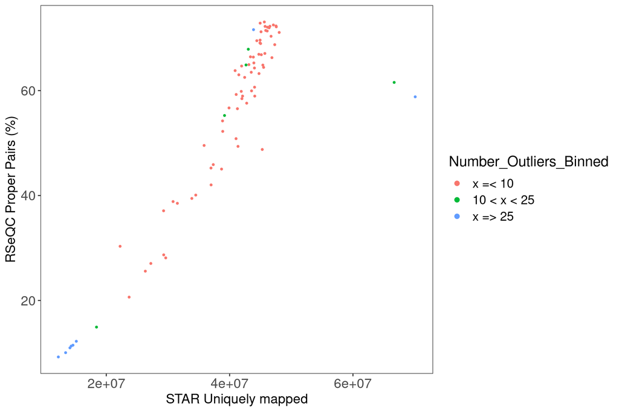

```r
ggplot(as.data.frame(coldataNasal), aes(x = STAR_uniquely_mapped, y = RSeQC_proper_pairs_percent, color = Number_Outliers_Binned)) +
  geom_point(size = 0.75) +
  ggplot2::theme_bw() +
  ggplot2::theme(
    panel.grid.major = ggplot2::element_blank(),
    panel.grid.minor = ggplot2::element_blank(),
    axis.text = ggplot2::element_text(size = 14),
    axis.title = ggplot2::element_text(size = 14)
  ) +
  ggplot2::xlab(paste0("STAR Uniquely mapped")) +
  ggplot2::ylab(paste0("RSeQC Proper Pairs (%)")) +
  ggplot2::theme(legend.title = ggplot2::element_text(size = 15), legend.text = ggplot2::element_text(size = 13)) +
  ggplot2::guides(colour = ggplot2::guide_legend(override.aes = list(size = 2)))
```

### Proper Pairs Percent vs TIN median

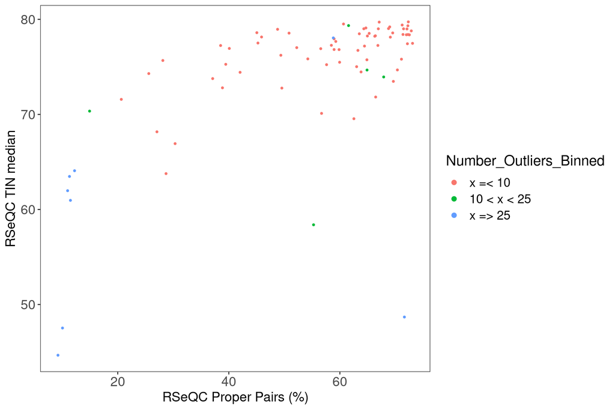

```r
ggplot(as.data.frame(coldataNasal), aes(x = RSeQC_proper_pairs_percent, y = RSeQC_TIN_median, color = Number_Outliers_Binned)) +
  geom_point(size = 0.75) +
  ggplot2::theme_bw() +
  ggplot2::theme(
    panel.grid.major = ggplot2::element_blank(),
    panel.grid.minor = ggplot2::element_blank(),
    axis.text = ggplot2::element_text(size = 14),
    axis.title = ggplot2::element_text(size = 14)
  ) +
  ggplot2::xlab(paste0("RSeQC Proper Pairs (%)")) +
  ggplot2::ylab(paste0("RSeQC TIN median")) +
  ggplot2::theme(legend.title = ggplot2::element_text(size = 15), legend.text = ggplot2::element_text(size = 13)) +
  ggplot2::guides(colour = ggplot2::guide_legend(override.aes = list(size = 2)))
```

## PCA, QC outliers

We used 96 QC metrics and computed the PCA on z-scored values. We subsequently ran Pearson correlation test on PC 1-10 and the z-score of each QC metric to calculate which principal component each QC metric was most strongly associated to.

### Outliers

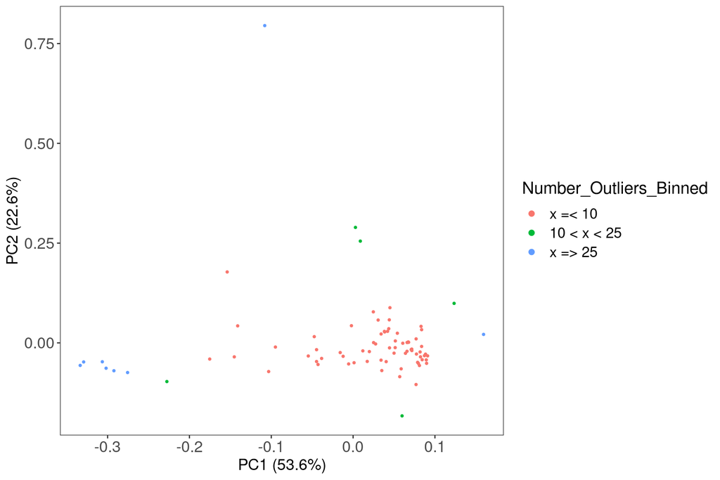

```r
qcMetrics <- colDataNasalSubset

qcMetrics.z <- t(scale(qcMetrics))

z <- qcMetrics.z

RIN <- annotNasal$RIN

Novartis_QC <- novartisQC

# run PCA
pc <- prcomp(z, center = F, scale = F)

spc <- summary(pc)
pc1Importance <- signif(spc$importance[2, 1] * 100, 3)
pc2Importance <- signif(spc$importance[2, 2] * 100, 3)

forpcaNasal <- as.data.frame(pc$rotation[, 1:3])

forpcaNasal$Number_Outliers_Binned <- Number_Outliers_Binned

# pdf("~/PCA_Batch.pdf", width = 9)
ggplot(forpcaNasal, aes(x = PC1, y = PC2, color = Number_Outliers_Binned)) +
  geom_point(size = 0.75) +
  ggplot2::theme_bw() +
  ggplot2::theme(
    panel.grid.major = ggplot2::element_blank(),
    panel.grid.minor = ggplot2::element_blank(),
    axis.text = ggplot2::element_text(size = 14),
    axis.title = ggplot2::element_text(size = 14)
  ) +
  ggplot2::xlab(paste0("PC1 (", pc1Importance, "%)")) +
  ggplot2::ylab(paste0("PC2 (", pc2Importance, "%)")) +
  ggplot2::theme(legend.title = ggplot2::element_text(size = 15), legend.text = ggplot2::element_text(size = 13)) +
  ggplot2::guides(colour = ggplot2::guide_legend(override.aes = list(size = 2)))
```

```r
cor1 <- cor(pc$rotation[,1:10], t(qcMetrics.z), method = "pearson")

cor1Res <- apply(cor1, 2, function(x){
    return(names(which.max(abs(x))))
})

uniquePCs <- unique(cor1Res)[order(unique(cor1Res))]
qcpc.list = list()
for(x in 1:length(uniquePCs)){
  pc <- uniquePCs[x]
  qcpc.list[[pc]] = names(cor1Res)[cor1Res == pc]
}

QCPC.table <- plyr::ldply(qcpc.list, cbind)
colnames(QCPC.table) <- c("PC", "Metric")

QCPC.table %>%
  knitr::kable(
    format = "html", align = rep("c", ncol(QCPC.table) + 1),
    row.names = TRUE
  ) %>%
  kableExtra::kable_styling() %>%
  kableExtra::scroll_box(height = "250px")
```

|  | PC | Metric |
| --- | --- | --- |
| 1 | PC1 | RSeQC_TIN_mean |
| 2 | PC1 | RSeQC_TIN_median |
| 3 | PC1 | RSeQC_splice_reads |
| 4 | PC1 | RSeQC_read_2 |
| 5 | PC1 | RSeQC_read_1 |
| 6 | PC1 | RSeQC_mapq_gte_mapq_cut_unique |
| 7 | PC1 | RSeQC_reads_mapped_in_proper_pairs |
| 8 | PC1 | RSeQC_mapq_lt_mapq_cut_non_unique |
| 9 | PC1 | RSeQC_non_splice_reads |
| 10 | PC1 | RSeQC_proper_pairs_percent |
| 11 | PC1 | RSeQC_reads_map_to_antisense |
| 12 | PC1 | RSeQC_total_records |
| 13 | PC1 | RSeQC_non_primary_hits |
| 14 | PC1 | RSeQC_unique_percent |
| 15 | PC1 | RSeQC_reads_map_to_sense |
| 16 | PC1 | RSeQC_total_splicing_events |
| 17 | PC1 | RSeQC_novel_splicing_junctions |
| 18 | PC1 | RSeQC_partial_novel_splicing_events_pct |
| 19 | PC1 | RSeQC_partial_novel_splicing_junctions |
| 20 | PC1 | RSeQC_known_splicing_junctions |
| 21 | PC1 | RSeQC_novel_splicing_events_pct |
| 22 | PC1 | RSeQC_total_splicing_junctions |
| 23 | PC1 | RSeQC_partial_novel_splicing_junctions_pct |
| 24 | PC1 | RSeQC_novel_splicing_events |
| 25 | PC1 | RSeQC_known_splicing_events |
| 26 | PC1 | RSeQC_partial_novel_splicing_events |
| 27 | PC1 | RSeQC_known_splicing_events_pct |
| 28 | PC1 | RSeQC_tes_down_1kb_tags_kb |
| 29 | PC1 | RSeQC_cds_exons_tag_count |
| 30 | PC1 | RSeQC_5_utr_exons_tags_kb |

[output cut: 66 more lines]

Of all of the QC metrics, 64 were most associated, either positively or negatively, to PC1.

### Outliers, Novartis

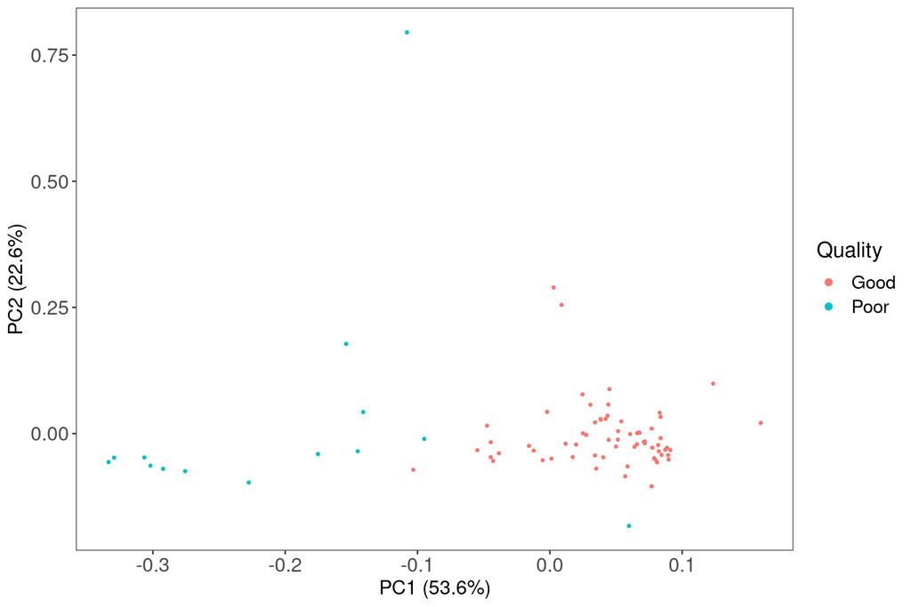

```r
forpcaNasal$Quality <- Novartis_QC

# pdf("~/PCA_Batch.pdf", width = 9)
ggplot(forpcaNasal, aes(x = PC1, y = PC2, color = Quality)) +
  geom_point(size = 0.75) +
  ggplot2::theme_bw() +
  ggplot2::theme(
    panel.grid.major = ggplot2::element_blank(),
    panel.grid.minor = ggplot2::element_blank(),
    axis.text = ggplot2::element_text(size = 14),
    axis.title = ggplot2::element_text(size = 14)
  ) +
  ggplot2::xlab(paste0("PC1 (", pc1Importance, "%)")) +
  ggplot2::ylab(paste0("PC2 (", pc2Importance, "%)")) +
  ggplot2::theme(legend.title = ggplot2::element_text(size = 15), legend.text = ggplot2::element_text(size = 13)) +
  ggplot2::guides(colour = ggplot2::guide_legend(override.aes = list(size = 2)))
```

```r
seNasal <- se[, which(colnames(se) %in% annotNasal$`RNA Sample ID`)]

annotNasal <- annotNasal[annotNasal$`RNA Sample ID` %in% colnames(se), ]

# reorder
annotNasal <- annotNasal[match(colnames(seNasal), annotNasal$`RNA Sample ID`), ]

counts <- assays(seNasal)[[2]]

counts <- counts[rowSums(counts) > 0, ]

# z normalize
z <- t(scale(t(counts)))
# run PCA
pc <- prcomp(z, center = F, scale = F)

forpcaNasal <- as.data.frame(pc$rotation[, 1:3])

forpcaNasal$Batch <- annotNasal$Batch

spc <- summary(pc)
pc1Importance <- signif(spc$importance[2, 1] * 100, 3)
pc2Importance <- signif(spc$importance[2, 2] * 100, 3)
pc3Importance <- signif(spc$importance[2, 3] * 100, 3)
```

## Heatmap, QC outliers

The numeric QC metric values were z-scored across samples, plotted by heatmap. A total of 96 QC metrics were used.

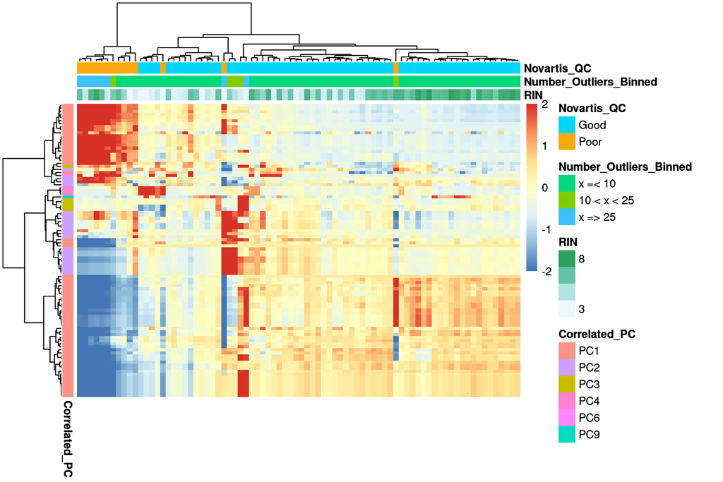

```r
qcMetrics <- colDataNasalSubset

qcMetrics.z <- t(scale(qcMetrics))
qcMetrics.z.trim <- qcMetrics.z

qcMetrics.z.trim[qcMetrics.z < -2] <- -2
qcMetrics.z.trim[qcMetrics.z > 2] <- 2

RIN <- annotNasal$RIN

Number_Outliers_Binned <- as.factor(qualAnnot)
Number_Outliers_Binned <- factor(Number_Outliers_Binned, levels = c("x =< 10",
                                    "10 < x < 25",
                                    "x => 25"))

Novartis_QC <- novartisQC
annotation_col <- data.frame(RIN, Number_Outliers_Binned, Novartis_QC)

rownames(annotation_col) <- colnames(qcMetrics.z.trim)

annotation_row <- data.frame(Correlated_PC = cor1Res)
rownames(annotation_row) <- rownames(qcMetrics.z.trim)

callback <- function(hc, mat) {
  sv <- svd(t(mat))$v[, 1]
  dend <- reorder(as.dendrogram(hc), wts = sv)
  as.hclust(dend)
}

out <- pheatmap(qcMetrics.z.trim,clustering_method = "ward.D2",
  color = colorRampPalette(rev(brewer.pal(n = 7, name = "RdYlBu")))(100),
  annotation_col = annotation_col,
  annotation_row = annotation_row,
  legend = T,
  show_rownames = F,
  show_colnames = F,
  fontsize_row = 9,
  cluster_rows = TRUE,
  cluster_cols = TRUE,
  clustering_callback = callback
)

out
```

```r
##Added 10/26/20. Used cutree to determine which samples to remove

clusterLabels <- sort(cutree(out$tree_col, k=2))
write.table(x = names(clusterLabels[clusterLabels == 2]),
        file = "20201026_PoorQuality_Nasal.txt", sep = "\t", row.names = F, col.names = F)
removed <- names(clusterLabels[clusterLabels == 2])
```

We split the dendrogram into 2 “branches” and considered all samples within the branch enriched for poor QC metrics to be of poor quality. These 11 samples are the following: EM15-14, EM15-31, EM15-64, EM15-85, EM16-194, EM16-195, EM16-228, N1-125, N1-139, N2-18, N2-30

## PCA, Batch Effect

There was no strong evidence of batch effect, although there may be a slight batch effect in Batch 4.

### PC1 vs PC2

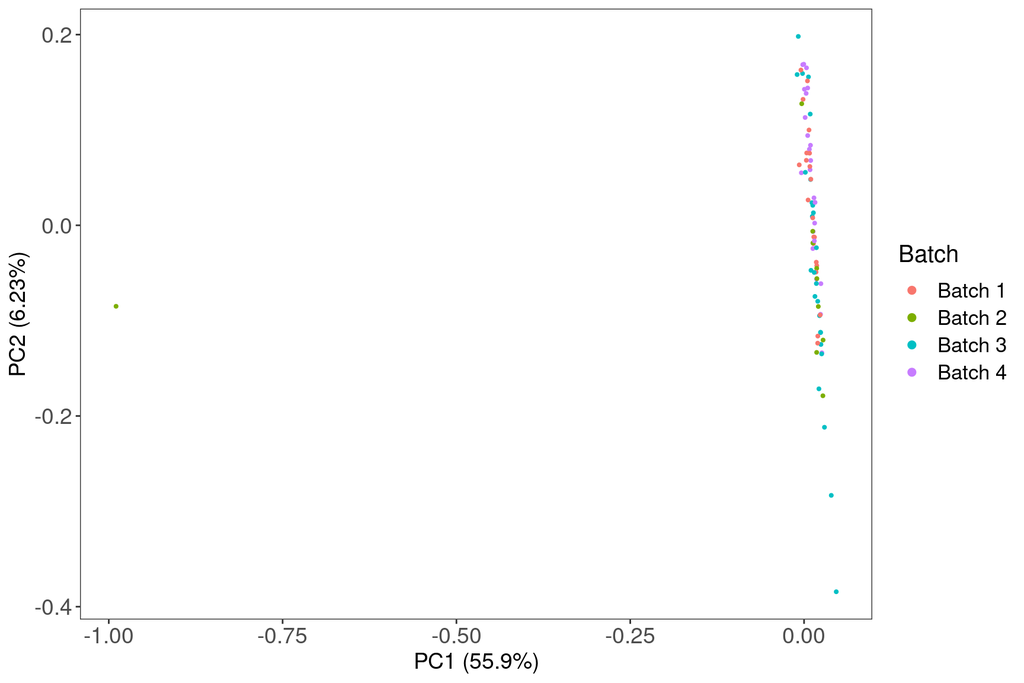

```r
# pdf("~/PCA_Batch.pdf", width = 9)
ggplot(forpcaNasal, aes(x = PC1, y = PC2, color = Batch)) +
  geom_point(size = 0.75) +
  ggplot2::theme_bw() +
  ggplot2::theme(
    panel.grid.major = ggplot2::element_blank(),
    panel.grid.minor = ggplot2::element_blank(),
    axis.text = ggplot2::element_text(size = 14),
    axis.title = ggplot2::element_text(size = 14)
  ) +
  ggplot2::xlab(paste0("PC1 (", pc1Importance, "%)")) +
  ggplot2::ylab(paste0("PC2 (", pc2Importance, "%)")) +
  ggplot2::theme(legend.title = ggplot2::element_text(size = 15), legend.text = ggplot2::element_text(size = 13)) +
  ggplot2::guides(colour = ggplot2::guide_legend(override.aes = list(size = 2)))
```

```r
# dev.off()
```

### PC1 vs PC3

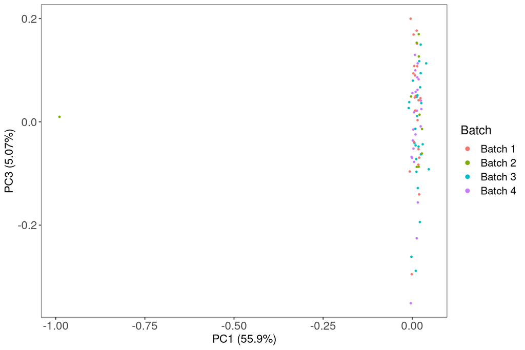

```r
ggplot(forpcaNasal, aes(x = PC1, y = PC3, color = Batch)) +
  geom_point(size = 0.75) +
  ggplot2::theme_bw() +
  ggplot2::theme(
    panel.grid.major = ggplot2::element_blank(),
    panel.grid.minor = ggplot2::element_blank(),
    axis.text = ggplot2::element_text(size = 14),
    axis.title = ggplot2::element_text(size = 14)
  ) +
  ggplot2::xlab(paste0("PC1 (", pc1Importance, "%)")) +
  ggplot2::ylab(paste0("PC3 (", pc3Importance, "%)")) +
  ggplot2::theme(legend.title = ggplot2::element_text(size = 15), legend.text = ggplot2::element_text(size = 13)) +
  ggplot2::guides(colour = ggplot2::guide_legend(override.aes = list(size = 2)))
```

### PC2 vs PC3

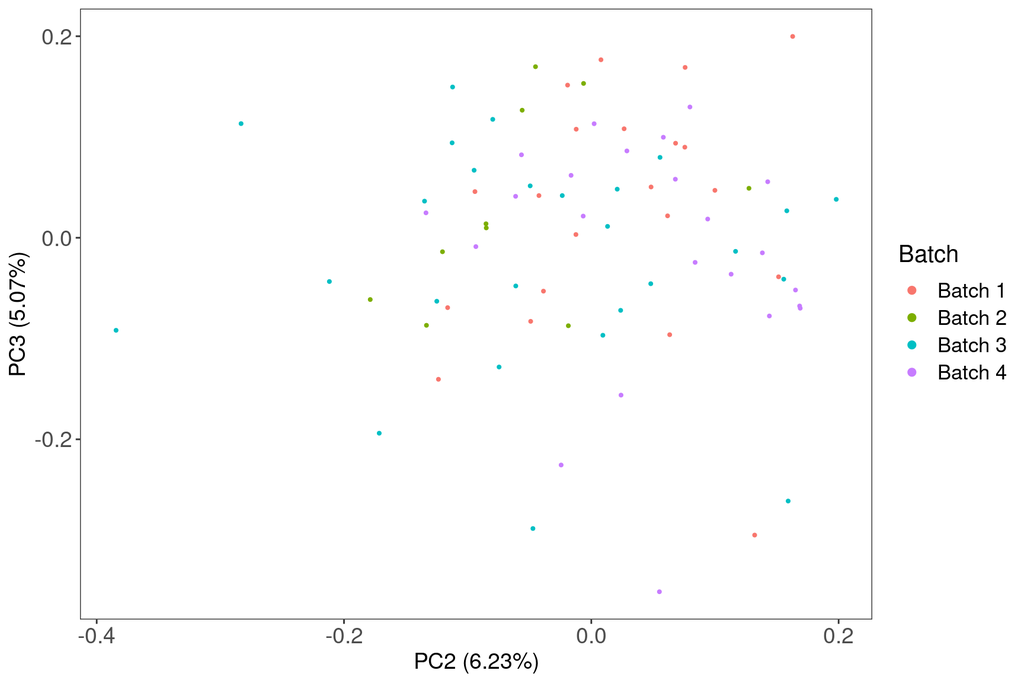

```r
ggplot(forpcaNasal, aes(x = PC2, y = PC3, color = Batch)) +
  geom_point(size = 0.75) +
  ggplot2::theme_bw() +
  ggplot2::theme(
    panel.grid.major = ggplot2::element_blank(),
    panel.grid.minor = ggplot2::element_blank(),
    axis.text = ggplot2::element_text(size = 14),
    axis.title = ggplot2::element_text(size = 14)
  ) +
  ggplot2::xlab(paste0("PC2 (", pc2Importance, "%)")) +
  ggplot2::ylab(paste0("PC3 (", pc3Importance, "%)")) +
  ggplot2::theme(legend.title = ggplot2::element_text(size = 15), legend.text = ggplot2::element_text(size = 13)) +
  ggplot2::guides(colour = ggplot2::guide_legend(override.aes = list(size = 2)))
```

### QC outliers

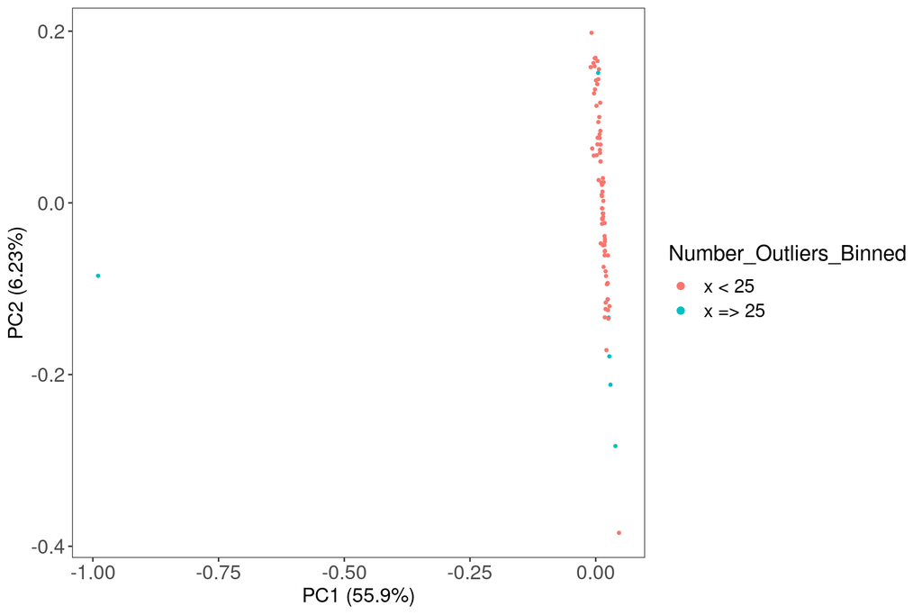

```r
forpcaNasal <- cbind(forpcaNasal, qc.tally.gg)
ggplot(forpcaNasal, aes(x = PC1, y = PC2, color = Number_Outliers_Binned)) +
  geom_point(size = 0.75) +
  geom_point(
    data = subset(forpcaNasal, Number_Outliers_Binned == "x >= 25"),
    aes(x = PC1, y = PC2, color = Number_Outliers_Binned)
  ) +
  ggplot2::theme_bw() +
  ggplot2::theme(
    panel.grid.major = ggplot2::element_blank(),
    panel.grid.minor = ggplot2::element_blank(),
    axis.text = ggplot2::element_text(size = 14),
    axis.title = ggplot2::element_text(size = 14)
  )  +
  ggplot2::xlab(paste0("PC1 (", pc1Importance, "%)")) +
  ggplot2::ylab(paste0("PC2 (", pc2Importance, "%)")) +
  ggplot2::theme(legend.title = ggplot2::element_text(size = 15), legend.text = ggplot2::element_text(size = 13)) +
  ggplot2::guides(colour = ggplot2::guide_legend(override.aes = list(size = 2)))
```

```r
outlierNasal1 <- rownames(forpcaNasal)[forpcaNasal$PC1 < -0.5]
```

The sample with the lowest PC1 value is N2-28.

## Sex status

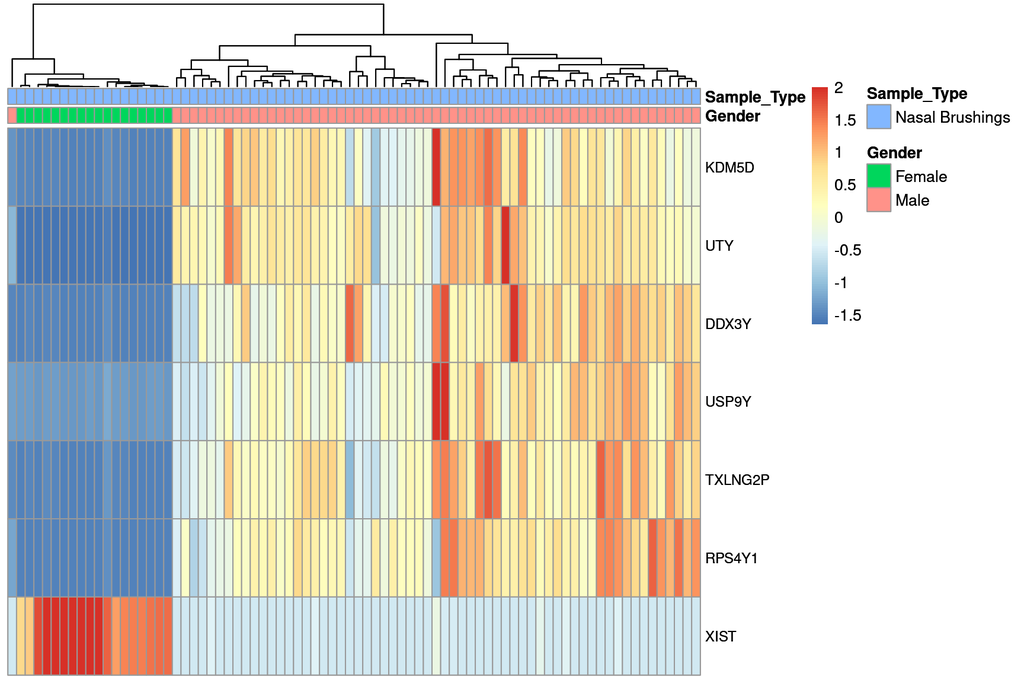

```r
sex.genes <- c("KDM5D", "UTY", "DDX3Y", "USP9Y", "TXLNG2P", "RPS4Y1", "XIST")
sex.genes.id <- match(sex.genes, rowRanges(seNasal)$external_gene_id)

Gender <- annotNasal$PERSON_GENDER
Sample_Type <- annotNasal$`Sample Type`
Gender <- gsub(" Gender", "", Gender)
annotation_col <- data.frame(Gender, Sample_Type)

counts <- assays(seNasal)$TPM
rownames(counts) <- rowRanges(seNasal)$external_gene_id

genes1 <- counts[sex.genes.id, ]

genes1.z <- t(scale(t(genes1)))
genes1.z.trim <- genes1.z
genes1.z.trim[genes1.z < -2] <- -2
genes1.z.trim[genes1.z > 2] <- 2

rownames(annotation_col) <- colnames(genes1.z.trim)

out <- pheatmap(genes1.z.trim,
  color = colorRampPalette(rev(brewer.pal(n = 7, name = "RdYlBu")))(100),
  annotation_col = annotation_col,
  legend = T,
  show_rownames = T,
  show_colnames = F,
  fontsize_row = 9,
  cluster_rows = FALSE
)

exprs.female <- which(genes1.z.trim["KDM5D", ] < -1)
record.male <- which(annotNasal$PERSON_GENDER == "Male Gender")
sex.discrepancy <- annotNasal$`Kit Number`[intersect(exprs.female, record.male)]

out
```

The patient not expressing male sex-linked genes, but annotated male, is 4795-112

## Demographics Comparison

General annotation data of patients were compared between those of which samples were removed due to outliers, and those that were retained.

```r
seNasalQC <- seNasal[, !colnames(seNasal) %in% highAmountOutlier]
annotNasalQC <- annotNasal[!annotNasal$`RNA Sample ID` %in% highAmountOutlier, ]

seNasalQCOut <- seNasal[, colnames(seNasal) %in% highAmountOutlier]
annotNasalQCOut <- annotNasal[annotNasal$`RNA Sample ID` %in% highAmountOutlier, ]

lab <- c(
  rep("Retained", length(annotNasalQC$GRPB_SMK_STS)),
  rep("Removed", length(annotNasalQCOut$GRPB_SMK_STS))
)
# AGE
mean.age <- mean(annotNasalQC$AGE)
sd.age <- sd(annotNasalQC$AGE)

age <- paste0(signif(mean.age, 3), " +/- ", signif(sd.age, 3))

mean.age.rm <- mean(annotNasalQCOut$AGE)
sd.age.rm <- sd(annotNasalQCOut$AGE)

age.rm <- paste0(signif(mean.age.rm, 3), " +/- ", signif(sd.age.rm, 3))

age.pvalue <- signif(wilcox.test(annotNasalQC$AGE, annotNasalQCOut$AGE)$p.value, 3)

demo.table <- c(age, age.rm, age.pvalue)

# Gender
gstatus <- c(annotNasalQC$PERSON_GENDER, annotNasalQCOut$PERSON_GENDER)

male.ct <- sum(annotNasalQC$PERSON_GENDER == "Male Gender")
male.pct <- signif(male.ct / length(annotNasalQC$PERSON_GENDER), 3) * 100
male <- paste0("Male: ", male.ct, "(", male.pct, "%)")

male.ct.rm <- sum(annotNasalQCOut$PERSON_GENDER == "Male Gender")
male.pct.rm <- signif(male.ct.rm / length(annotNasalQCOut$PERSON_GENDER), 3) * 100
male.rm <- paste0("Male: ", male.ct.rm, "(", male.pct.rm, "%)")

gender.pvalue <- signif(chisq.test(table(lab, gstatus))$p.value, 3)

demo.table <- rbind(demo.table, c(male, male.rm, gender.pvalue))

# FEVFVC
mean.fevfvc <- mean(annotNasalQC$FEV_FVC)
sd.fevfvc <- sd(annotNasalQC$FEV_FVC)

fevfvc <- paste0(signif(mean.fevfvc, 3), " +/- ", signif(sd.fevfvc, 3))

mean.fevfvc.rm <- mean(annotNasalQCOut$FEV_FVC)
sd.fevfvc.rm <- sd(annotNasalQCOut$FEV_FVC)

fevfvc.rm <- paste0(signif(mean.fevfvc.rm, 3), " +/- ", signif(sd.fevfvc.rm, 3))

fevfvc.pvalue <- signif(wilcox.test(annotNasalQC$FEV_FVC, annotNasalQCOut$FEV_FVC)$p.value, 3)

demo.table <- rbind(demo.table, c(fevfvc, fevfvc.rm, fevfvc.pvalue))


# Smoking Status
smk <- c(annotNasalQC$GRPB_SMK_STS, annotNasalQCOut$GRPB_SMK_STS)

annotNasalQC$GRPB_SMK_STS <- gsub(" ", "_", annotNasalQC$GRPB_SMK_STS)
annotNasalQCOut$GRPB_SMK_STS <- gsub(" ", "_", annotNasalQCOut$GRPB_SMK_STS)

smkstatus.na <- sum(is.na(annotNasalQC$GRPB_SMK_STS == "Current_Smoker"))

smkstatus.ct <- sum(annotNasalQC[!is.na(annotNasalQC$GRPB_SMK_STS), ]$GRPB_SMK_STS == "Current_Smoker")
smkstatus.pct <- signif(smkstatus.ct / nrow(annotNasalQC[!is.na(annotNasalQC$GRPB_SMK_STS), ]), 3) * 100
smkstatus <- paste0("Current: ", smkstatus.ct, "(", smkstatus.pct, "%)")

smkstatus.ct.rm <- sum(annotNasalQCOut$GRPB_SMK_STS == "Current_Smoker")
smkstatus.pct.rm <- signif(smkstatus.ct.rm / length(annotNasalQCOut$GRPB_SMK_STS), 3) * 100
smkstatus.rm <- paste0("Current: ", smkstatus.ct.rm, "(", smkstatus.pct.rm, "%)")

smkstatus.pvalue <- signif(chisq.test(table(lab, smk))$p.value, 3)

demo.table <- rbind(demo.table, c(smkstatus, smkstatus.rm, smkstatus.pvalue))

rownames(demo.table) <- c("Age", "Gender", "FEV1/FVC", "Smoking Status")
colnames(demo.table) <- c("Retained", "Removed", "p-value")

demo.table %>%
  knitr::kable(
    format = "html", align = rep("c", ncol(demo.table) + 1),
    row.names = TRUE
  ) %>%
  kableExtra::kable_styling()
```

|  | Retained | Removed | p-value |
| --- | --- | --- | --- |
| Age | 62.3 +/- 5.97 | 62.9 +/- 5.82 | 0.845 |
| Gender | Male: 51(76.1%) | Male: 11(84.6%) | 0.758 |
| FEV1/FVC | 0.649 +/- 0.137 | 0.616 +/- 0.139 | 0.43 |
| Smoking Status | Current: 25(37.3%) | Current: 5(38.5%) | 1 |

## Differential Expression, Smoking status

DESeq2 was run (Model: ~ Smoking Status) on both expression data prior to and after filtering possible outliers.

### Pre-filter

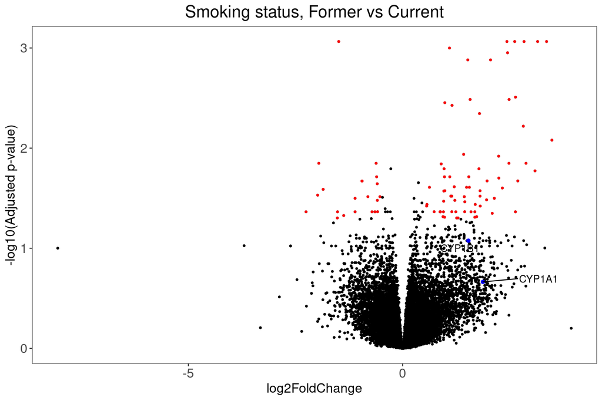

```r
counts <- assay(seNasal)
rownames(counts) <- rowRanges(seNasal)$external_gene_id

counts <- apply(counts, 1:2, function(x) {
  return(as.integer(x))
})

no.smk.status.ix <- which(is.na(annotNasal$GRPB_SMK_STS))

if (length(no.smk.status.ix) > 0) {
  counts <- counts[, -no.smk.status.ix]
  annotNasal <- annotNasal[-no.smk.status.ix, ]
}

annotNasal$GRPB_SMK_STS <- gsub(" ", "_", annotNasal$GRPB_SMK_STS)
# annotNasal$GRPB_SMK_STS <- as.factor(annotNasal$GRPB_SMK_STS)

dds <- DESeqDataSetFromMatrix(
  countData = counts,
  colData = annotNasal,
  design = ~GRPB_SMK_STS
)
dds$GRPB_SMK_STS <- relevel(dds$GRPB_SMK_STS, ref = "Former_Smoker")
keep <- rowSums(counts(dds)) >= 10
dds <- dds[keep, ]
dds <- DESeq(dds)
res <- results(dds)
# res


resOrdered <- res[order(res$pvalue), ]
resOrdered$nLogPVal <- -log10(resOrdered$padj)
# resOrdered
resOrdered <- as.data.frame(resOrdered)
resSig <- resOrdered %>%
  filter(padj < 0.05) %>%
  filter(abs(log2FoldChange) > 0.5)
numSig <- nrow(resSig)
numUp <- nrow(resSig[resSig$log2FoldChange > 0.5, ])
numDown <- nrow(resSig[resSig$log2FoldChange < -0.5, ])

labels <- sapply(rownames(resOrdered), function(x) {
  if (x %in% c("CYP1A1", "CYP1B1")) {
    return("red")
  } else {
    return("black")
  }
})

labeltxt <- sapply(rownames(resOrdered), function(x) {
  if (x %in% c("CYP1A1")) {
    return("CYP1A1")
  } else if (x %in% c("CYP1B1")) {
    return("CYP1B1")
  } else {
    return("")
  }
})
resOrderedCYP <- resOrdered[c("CYP1A1", "CYP1B1"), ]

ggplot(resOrdered, aes(x = log2FoldChange, y = nLogPVal)) +
  geom_point(size = 0.75) +
  ggplot2::theme_bw() +
  ggplot2::theme(
    panel.grid.major = ggplot2::element_blank(),
    panel.grid.minor = ggplot2::element_blank(),
    axis.text = ggplot2::element_text(size = 14),
    axis.title = ggplot2::element_text(size = 14)
  ) +
  ggplot2::theme(legend.title = ggplot2::element_text(size = 15), legend.text = ggplot2::element_text(size = 13)) +
  ggplot2::guides(
    colour =
      ggplot2::guide_legend(override.aes = list(size = 2))
  ) + geom_point(data = resSig, aes(x = log2FoldChange, y = nLogPVal), color = "Red"
                 ,size = 0.75) +
  geom_point(data = resOrderedCYP, aes(x = log2FoldChange, y = nLogPVal), color = "blue") +
  ggrepel::geom_text_repel(aes(x = log2FoldChange, y = nLogPVal), label = labeltxt) +
  ggplot2::labs(y = "-log10(Adjusted p-value)") +
  ggplot2::ggtitle(label = "Smoking status, Former vs Current") +
  ggplot2::theme(plot.title = ggplot2::element_text(
    hjust = 0.5,
    size = 18
  ))
```

### Post-filter

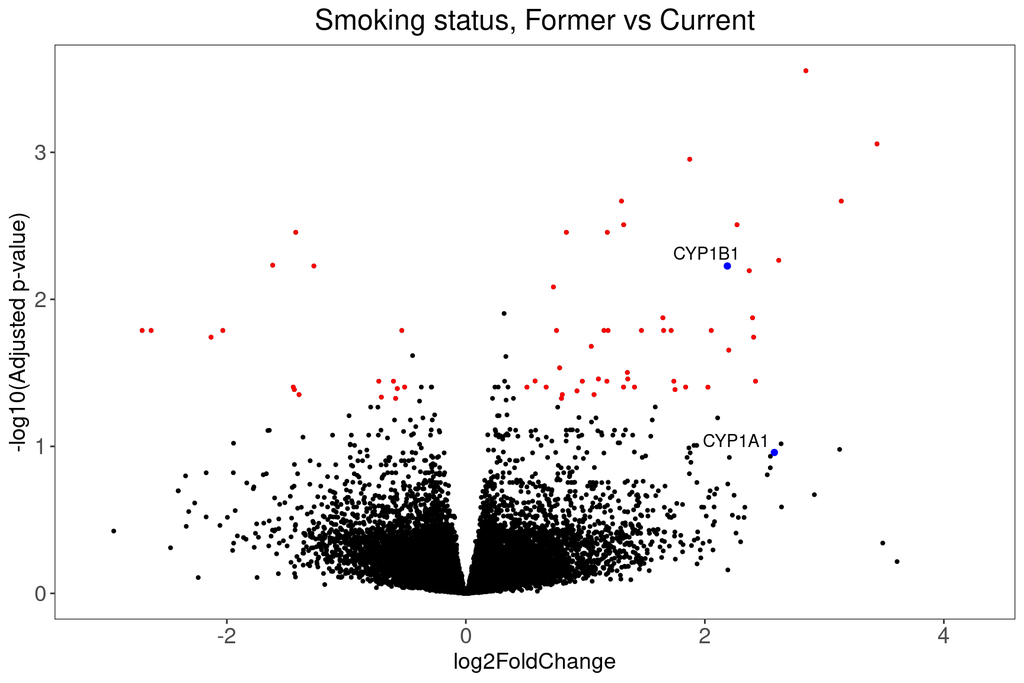

```r
counts <- assay(seNasalQC)
rownames(counts) <- rowRanges(seNasal)$external_gene_id

counts <- apply(counts, 1:2, function(x) {
  return(as.integer(x))
})

annotNasalQC$GRPB_SMK_STS <- gsub(" ", "_", annotNasalQC$GRPB_SMK_STS)
annotNasalQC$GRPB_SMK_STS <- factor(annotNasalQC$GRPB_SMK_STS, levels = c("Current_Smoker", "Former_Smoker"))

no.smk.status.ix <- which(is.na(annotNasalQC$GRPB_SMK_STS))

if (length(no.smk.status.ix) > 0) {
  counts <- counts[, -no.smk.status.ix]
  annotNasal <- annotNasal[-no.smk.status.ix, ]
}

dds <- DESeqDataSetFromMatrix(
  countData = counts,
  colData = annotNasalQC,
  design = ~GRPB_SMK_STS
)
dds$GRPB_SMK_STS <- relevel(dds$GRPB_SMK_STS, ref = "Former_Smoker")
keep <- rowSums(counts(dds)) >= 10
dds <- dds[keep, ]
dds <- DESeq(dds)
res <- results(dds)

resOrdered <- res[order(res$pvalue), ]

resOrdered <- as.data.frame(resOrdered)
resOrdered$nLogPVal <- -log10(resOrdered$padj)
resSig <- resOrdered %>%
  filter(padj < 0.05) %>%
  filter(abs(log2FoldChange) > 0.5)
numSigQC <- nrow(resSig)
numUpQC <- nrow(resSig[resSig$log2FoldChange > 0.5, ])
numDownQC <- nrow(resSig[resSig$log2FoldChange < -0.5, ])

labeltxt <- sapply(rownames(resOrdered), function(x) {
  if (x %in% c("CYP1A1")) {
    return("CYP1A1")
  } else if (x %in% c("CYP1B1")) {
    return("CYP1B1")
  } else {
    return("")
  }
})
resOrderedCYP <- resOrdered[c("CYP1A1", "CYP1B1"), ]

ggplot(resOrdered, aes(x = log2FoldChange, y = nLogPVal)) +
  geom_point(size = 0.75) +
  ggplot2::theme_bw() +
  ggplot2::theme(
    panel.grid.major = ggplot2::element_blank(),
    panel.grid.minor = ggplot2::element_blank(),
    axis.text = ggplot2::element_text(size = 14),
    axis.title = ggplot2::element_text(size = 14)
  ) +
  ggplot2::theme(legend.title = ggplot2::element_text(size = 15), legend.text = ggplot2::element_text(size = 13)) +
  ggplot2::guides(
    colour =
      ggplot2::guide_legend(override.aes = list(size = 2))
  ) + geom_point(data = resSig, aes(x = log2FoldChange, y = nLogPVal), color = "Red",
                 size = 0.75) +
  geom_point(data = resOrderedCYP, aes(x = log2FoldChange, y = nLogPVal), color = "blue") +
  ggrepel::geom_text_repel(aes(x = log2FoldChange, y = nLogPVal), label = labeltxt) +
  ggplot2::labs(y = "-log10(Adjusted p-value)") +
  ggplot2::ggtitle(label = "Smoking status, Former vs Current") +
  ggplot2::theme(plot.title = ggplot2::element_text(
    hjust = 0.5,
    size = 18
  ))
```

A total of 90(69 Upregulated, 21 Downregulated) and 62(45 Upregulated, 17 Downregulated) were differentially expressed pre- and post- filter, respectively (padj < 0.05, abs(log2FC) > 0.5).

## Reproducibility

**For reproducibility:**

```r
## datetime

Sys.time()
```

```
## [1] "2020-11-05 15:11:22 EST"
```